# Targeted urine metabolomics analysis

Rafael Riudavets Puig

2026-10-02

# Targeted urine GC-MS data

This notebook contains the steps for the analysis of the targeted GC-MS urine metabolomics data of the Lactobreath project.

## Library loading

Below are all the required libraries for the script.

```r
library(readxl)
library(writexl)
library(FactoMineR)
library(reshape2)
library(ggplot2)
library(stringr)
library(rstatix)
library(purrr)
library(forcats)
library(nparLD)
library(ggpubr)
library(ComplexHeatmap)
library(gridExtra)
library(cowplot)
library(rmarkdown)
library(FSA)
library(lme4)
library(lmerTest)
library(tidyr)
library(dplyr)
library(this.path)
```

```r
setwd(this.dir())
source("urine_metabolome_utils.R")

# Define output directories for results
output_dir = file.path(getwd(), "results")
raw_results_dir = file.path(output_dir, "raw_data")
plots_dir = file.path(output_dir, "plots")
descriptive_plots_dir = file.path(plots_dir, "cohort_descriptives")
qc_plots_dir = file.path(plots_dir, "qc_plots")
eda_plots_dir = file.path(plots_dir, "EDA_plots")
dea_dir = file.path(output_dir, "DEA")
pub_dir = file.path(output_dir, "pub_plots") #Plots for publication

dirs = c(output_dir, raw_results_dir, plots_dir, descriptive_plots_dir, qc_plots_dir, eda_plots_dir, dea_dir)


for (d in dirs) {
  if (!dir.exists(d)) {
    dir.create(d, recursive = TRUE)
  }
}
```

## Reading and preparing the input data

The input data are multiple excel files - one for each batch. While reading it, we want turn the two-level column title system into one level. After reading it, we start by adding some information like the batch, injection order, and type of sample.

```r
# Import list of files
raw_path <- file.path(this.dir(), "raw_data")
files = list.files(raw_path, pattern = "^Batch.*\\.xlsx$", full.names = TRUE)

# Transform two-level column titles to one-level
batches = lapply(files, function(x) {clean_headers(x, remove_second_lactose_peak = TRUE)})

# Put all batches into one data frame
data = do.call(rbind, batches)
# Order data by injection time and create injection order column
data$injection_order = as.numeric(sapply(strsplit(data$`Data File`, "_"), "[[", 1))
data = data[order(data$injection_order, decreasing = FALSE), ]

# Define sample type (overwrite the already existing column in raw data)
data = data %>%
  mutate(
    Type = case_when(
      grepl("^[0-9]", Name) ~ "Sample",
      grepl("QC", Name) ~ "QC",
      grepl("^Std", Name) ~ "Std",
      grepl("blank", Name, ignore.case = TRUE) ~ "Blank",
      grepl("^Bla", Name) ~ "Blank",
      TRUE ~ "NA"
    ),
    batch = factor(batch, levels = as.character(sort(as.numeric(unique(batch)))))
  ) %>%
  filter(!grepl("_Eq", Name))

# Add an extra number to the standard Name so that we know if it's the first or second
# standard round within a batch
# Batch 16 got some extra standards at the higher range
standard_order_nums = rep(rep(1:2, each = 6), 15)
standard_order_nums = c(standard_order_nums, rep(1:2, each = 9))
# Batch 17 has again 6 standards
standard_order_nums = c(standard_order_nums, rep(1:2, each = 6))
data$Name[grep("Std_", data$Name)] = paste0(data$Name[grep("Std_", data$Name)], "_", standard_order_nums)

# Convert response columns to numeric
# Also convert NAs to 0 to avoid NA propagation
data[grep("Resp.", colnames(data), fixed = TRUE)] = lapply(data[grep("Resp.", colnames(data), fixed = TRUE)], function(x) {
  num = as.numeric(gsub(",", "", x))
  num[is.na(num)] = 0
  return(num)
})

# Remove column that contains no information
data = data[, -grep("Level", colnames(data))]

# Filter out samples that were repeated in batches 16 and 17 due to low quality
repeated_samples = data %>%
  filter(batch %in% c(16, 17)) %>%
  filter(Type == "Sample") %>%
  mutate(Name = gsub("_rep", "", Name)) %>%
  pull(Name)

# Finish preparing and filter LB122 because it does not have a baseline sample
data = data %>%
  filter(!Name %in% repeated_samples) %>%
  mutate(Name = gsub("_rep", "", Name)) %>%
  filter(Name != "QC16e") %>%
  filter(!grepl("122_", Name))

write.table(
  data,
  file.path(raw_results_dir, "1_prepared_raw_data.tsv"),
  sep = "\t",
  col.names = TRUE,
  row.names = FALSE,
  quote = FALSE
)
```

```r
paged_table(data)
```

| Name | Data File | Type | Acq. Date-Time | IStd Xylose RT | IStd Xylose Resp. | IStd Fructose RT | IStd Fructose Resp. | 1,4-Galactonolactone RT | 1,4-Galactonolactone Resp. | Galactose Pk1 RT | Galactose Pk1 Resp. | Galactose Pk2 RT | Galactose Pk2 Resp. | Galactitol RT | Galactitol Resp. | 1,5-Galactonolactone RT | 1,5-Galactonolactone Resp. | Galactonate RT | Galactonate Resp. | Lactose Pk1 RT | Lactose Pk1 Resp. | Lactose Pk2 RT | Lactose Pk2 Resp. | batch | injection_order |
| --- | --- | --- | --- | --- | --- | --- | --- | --- | --- | --- | --- | --- | --- | --- | --- | --- | --- | --- | --- | --- | --- | --- | --- | --- | --- |
| QC1a | 26022402_QC1a.D | QC | 46077.7187984259 | 24.0370833333333 | 4844853.7 | 28.660633333333301 | 5096440.0 | 28.770883333333298 | 1.247360e+06 | 29.043233333333301 | 8.439534e+05 | 29.438800000000001 | 1.880926e+05 | 30.0224166666667 | 8.665521e+05 | 30.223433333333301 | 32085.0221 | 31.092383333333299 | 4.265983e+05 | 42.797150000000002 | 2.628268e+06 | 43.024099999999997 | 467758.5895 | 1 | 26022402 |
| Std_0_1 | 26022403_Std_0.D | Std | 46077.7713854514 | 24.0370666666667 | 5223212.1 | 28.660616666666701 | 5443892.8 | 28.770849999999999 | 1.361607e+06 | 29.043216666666702 | 9.115299e+05 | 29.438783333333301 | 2.064614e+05 | 30.022400000000001 | 9.533577e+05 | 30.223416666666701 | 33980.4839 | 31.09235 | 4.688345e+05 | 42.797133333333299 | 2.766528e+06 | 43.024083333333301 | 487530.5263 | 1 | 26022403 |
| Std_1_1 | 26022404_Std_1.D | Std | 46077.823945463002 | 24.0371666666667 | 4868511.6 | 28.660716666666701 | 4979457.5 | 28.770949999999999 | 2.070685e+06 | 29.043299999999999 | 1.747320e+06 | 29.438866666666701 | 3.743942e+05 | 30.015999999999998 | 1.071207e+06 | 30.223500000000001 | 45402.7362 | 31.092449999999999 | 8.178243e+05 | 42.797216666666699 | 3.598311e+06 | 43.024183333333298 | 606383.0507 | 1 | 26022404 |
| Std_2_1 | 26022405_Std_2.D | Std | 46077.876524629602 | 24.036899999999999 | 4915686.7 | 28.660450000000001 | 5106024.3 | 28.770683333333299 | 2.537899e+06 | 29.043050000000001 | 2.108788e+06 | 29.438600000000001 | 4.314409e+05 | 30.015733333333301 | 1.230722e+06 | 30.22325 | 48326.2555 | 31.092183333333299 | 1.018495e+06 | 42.803449999999998 | 4.188559e+06 | 43.0239166666667 | 689116.0075 | 1 | 26022405 |
| Std_3_1 | 26022406_Std_3.D | Std | 46077.929120046298 | 24.036933333333302 | 5239019.7 | 28.6604833333333 | 5481089.0 | 28.7707333333333 | 3.339400e+06 | 29.049566666666699 | 2.728761e+06 | 29.438649999999999 | 5.339101e+05 | 30.022266666666699 | 1.519483e+06 | 30.216799999999999 | 63482.8410 | 31.092233333333301 | 1.372453e+06 | 42.803483333333297 | 6.398835e+06 | 43.030450000000002 | 1006553.2740 | 1 | 26022406 |
| Std_4_1 | 26022407_Std_4.D | Std | 46077.981694780101 | 24.037183333333299 | 4829479.8 | 28.660733333333301 | 5018190.8 | 28.777450000000002 | 4.124331e+06 | 29.0498166666667 | 3.757035e+06 | 29.438883333333301 | 7.009235e+05 | 30.022500000000001 | 1.674664e+06 | 30.2235333333333 | 75377.1395 | 31.092466666666699 | 1.778628e+06 | 42.803733333333298 | 6.914541e+06 | 43.0242 | 1089377.3318 | 1 | 26022407 |
| Std_5_1 | 26022408_Std_5.D | Std | 46078.034282673601 | 24.0370666666667 | 5143959.5 | 28.660616666666701 | 5367718.3 | 28.777333333333299 | 5.774494e+06 | 29.049700000000001 | 5.373713e+06 | 29.445250000000001 | 1.003464e+06 | 30.022383333333298 | 2.120783e+06 | 30.223416666666701 | 96034.6938 | 31.0988333333333 | 2.599086e+06 | 42.803616666666699 | 9.904457e+06 | 43.030566666666701 | 1564536.6267 | 1 | 26022408 |
| QC1b | 26022409_QC1b.D | QC | 46078.086838483803 | 24.043533333333301 | 6803228.5 | 28.667066666666699 | 7415589.3 | 28.7773166666667 | 2.141614e+06 | 29.049666666666699 | 1.423416e+06 | 29.445233333333299 | 3.100327e+05 | 30.022366666666699 | 1.391501e+06 | 30.229866666666702 | 52365.4332 | 31.092333333333301 | 7.119653e+05 | 42.8035833333333 | 5.276179e+06 | 43.030549999999998 | 875157.5528 | 1 | 26022409 |
| Blank1a | 26022410_Blank1a.D | Blank | 46078.139441631902 | 24.037016666666698 | 6841175.2 | 28.6605666666667 | 7347293.0 | 28.861599999999999 | 0.000000e+00 | 29.166366666666701 | 0.000000e+00 | 29.166366666666701 | 0.000000e+00 | 29.9445333333333 | 0.000000e+00 | 30.100166666666698 | 0.0000 | 31.098800000000001 | 0.000000e+00 | 42.881383333333297 | 0.000000e+00 | 42.881383333333297 | 0.0000 | 1 | 26022410 |
| 113_2_A_BL | 26022411_113_2_A_BL.D | Sample | 46078.192043171301 | 24.043500000000002 | 6342197.4 | 28.66705 | 6843916.5 | 28.777283333333301 | 1.781505e+06 | 29.043150000000001 | 1.293123e+05 | 29.458166666666699 | 9.735939e+03 | 30.0288166666667 | 5.240431e+05 | 30.236316666666699 | 66608.4025 | 31.092300000000002 | 4.912531e+05 | 42.797066666666701 | 3.286084e+05 | 43.0110666666667 | 121489.8747 | 1 | 26022411 |

[output cut: 884 more lines]

## Descriptive statistics

```r
full_metadata <- read.delim("full_metadata.tsv")

metadata_new = read.csv(file.path(getwd(),"UrineGCMSAnalysisMetadata_20260430.csv"))
metadata_new = metadata_new %>%
  mutate(study_id_lb = gsub("_", "", study_id_lb)) #LB_XXX --> LBXXX
metadata_old = read_excel(file.path(getwd(), "UrineGCMSAnalysisMetadata_20250505.xlsx"))
# Upload metadata from pretest because manual corrections were carried out here for first 5 participants; see "Correction_fluid_consumption_first_five_participants.docx" for context
ids_corr = unique(metadata_old$study_id_lb)
metadata_new = metadata_new %>%
  filter(!study_id_lb %in% ids_corr)
# setdiff(names(metadata_old), names(metadata_new))
common_cols = intersect(names(metadata_new), names(metadata_old))
metadata_old_clean = metadata_old[, common_cols]
metadata_new_clean = metadata_new[, common_cols]
time_cols = grep(
  "time",
  names(metadata_new),
  ignore.case = TRUE,
  value = TRUE
)
metadata_new[time_cols] = lapply(metadata_new[time_cols], as.character)
metadata_old[time_cols] = lapply(metadata_old[time_cols], as.character)
metadata = bind_rows(metadata_new, metadata_old)

unblinding = read_excel(file.path(getwd(), "List_unblinding_final.xlsx"), col_names = FALSE)
colnames(unblinding) = c("int_group", "study_id_lb")

mapping = data %>%
  mutate(
    Name = Name,
    batch = batch,
    Type = Type,
  # Extract study ID where "Type" is a sample
    extracted_digits = if_else(
      Type == "Sample",
      str_extract(Name, "^[0-9]+"),
      NA_character_),
    study_id_lb = if_else(
      !is.na(extracted_digits),
      paste0("LB", str_pad(extracted_digits, width = 3, pad = "0")),
      NA_character_)
  ) %>%
  dplyr::select(study_id_lb, Name, Type, batch) %>%
  left_join(metadata[, c("study_id_lb", "screen_group", "sex")], by = "study_id_lb") %>%
  left_join(unblinding, by = "study_id_lb") %>%
  left_join(full_metadata %>% select(study_id, gen_test_rs4988235, ibs_sss_score), by = join_by("study_id_lb" == "study_id")) %>%
  mutate(
    timepoint = factor(case_when(
      grepl("AH", Name) ~ "At-home",
      grepl("BL", Name) ~ "Baseline",
      grepl("0-3", Name) ~ "0-3h",
      grepl("3-6", Name) ~ "3-6h")),
    screen_group = factor(case_when(
      screen_group == 1 ~ "Control",
      screen_group == 2 ~ "LM-A",
      screen_group == 3 ~ "LM-S"
    ), levels = c("Control", "LM-A", "LM-S")),
    batch = factor(batch),
    treatment = factor(case_when(
      int_group == "Treatment A" ~ "Lactose",
      int_group == "Treatment B" ~ "Glucose"
    ), levels = c("Lactose", "Glucose")),
    gen_test_rs4988235 = factor(gen_test_rs4988235, levels = c("TT", "CT", "CC"))
  )

write.table(
  mapping,
  file.path(raw_results_dir, "2_mapping.tsv"),
  sep = "\t",
  col.names = TRUE,
  row.names = FALSE,
  quote = FALSE
)

data = data %>%
  mutate(
    batch = factor(batch)
  )

# Number of sample types
samples_per_batch = data %>%
    group_by(batch) %>%
    summarise(Count = n()) %>%
    ggplot(aes(x = batch, y = Count, fill = batch)) +
        geom_bar(stat = "identity", position = "dodge") +
        ggtitle("Count of samples per batch") +
        theme_light()

samples_per_type = data %>%
    group_by(Type, batch) %>%
    summarise(Count = n()) %>%
    ggplot(aes(x = Type, y = Count, fill = batch)) +
        geom_bar(stat = "identity", position = "dodge") +
        ggtitle("Count of samples per type") +
        xlab("Sample type") +
        ylab("Count") +
        theme_light()

# Are the groups spread evenly across batches?
samples_per_batch_and_screen_group = data %>%
    filter(Type == "Sample") %>%
    left_join(mapping, by = "Name") %>%
    group_by(screen_group, batch.x) %>%
    summarise(n = n()) %>%
    ggplot(aes(x = batch.x, y = n, fill = screen_group)) +
        geom_bar(stat = "identity", position = "dodge") +
        ggtitle("Count of samples per batch and screen group") +
        xlab("Batch") +
        ylab("Count") +
        guides(
          fill = guide_legend(title = "Screen group")
        ) +
        scale_fill_manual(
          values = c(
            "Control" = "#619CFF",
            "LM-A" = "#00BA38",
            "LM-S" = "#F8766D"
          )
        ) +
        theme_light()

# Are the groups spread evenly across batches, including timepoints?
samples_per_batch_and_screen_group_and_timepoint = data %>%
    filter(Type == "Sample") %>%
    left_join(mapping, by = "Name") %>%
    group_by(screen_group, timepoint, batch.x) %>%
    summarise(n = n()) %>%
    ggplot(aes(x = batch.x, y = n, fill = screen_group)) +
        geom_bar(stat = "identity", position = "dodge") +
        ggtitle("Count of samples per batch and screen group by time point") +
        xlab("Batch") +
        ylab("Count") +
        facet_grid(timepoint ~ .) +
        guides(
          fill = guide_legend(title = "Screen group")
        ) +
        scale_fill_manual(
          values = c(
            "Control" = "#619CFF",
            "LM-A" = "#00BA38",
            "LM-S" = "#F8766D"
          )
        ) +
        theme_light()

# Are the groups spread evenly across batches, including timepoints?
samples_per_batch_and_screen_group_and_treatment = data %>%
    filter(Type == "Sample") %>%
    left_join(mapping, by = "Name") %>%
    group_by(screen_group, treatment, batch.x) %>%
    summarise(n = n()) %>%
    ggplot(aes(x = batch.x, y = n, fill = screen_group)) +
        geom_bar(stat = "identity", position = "dodge") +
        ggtitle("Count of samples per batch and screen group by treatment") +
        xlab("Batch") +
        ylab("Count") +
        facet_grid(treatment ~ .) +
        guides(
          fill = guide_legend(title = "Screen group")
        ) +
        scale_fill_manual(
          values = c(
            "Control" = "#619CFF",
            "LM-A" = "#00BA38",
            "LM-S" = "#F8766D"
          )
        ) +
        theme_light()
```

### Samples per batch

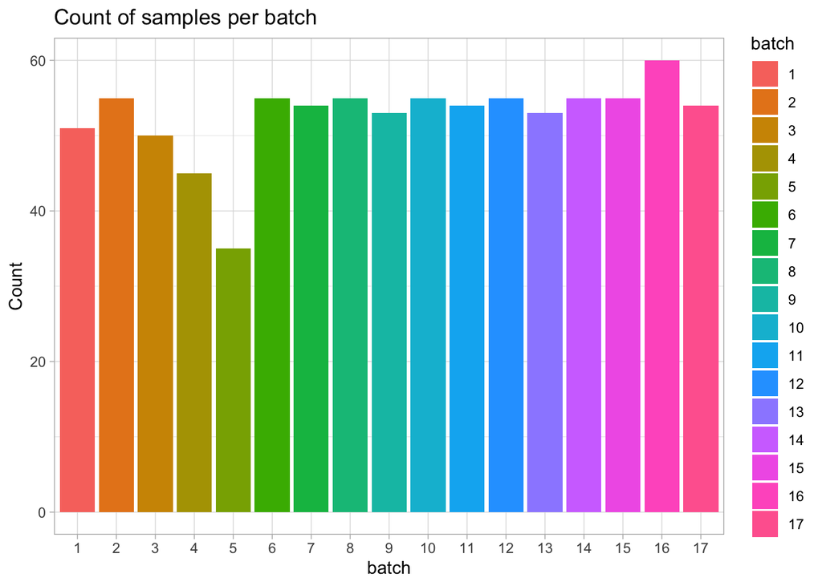

```r
ggsave(file.path(descriptive_plots_dir, "samples_per_batch.pdf"), samples_per_batch)
samples_per_batch
```

### Samples per type

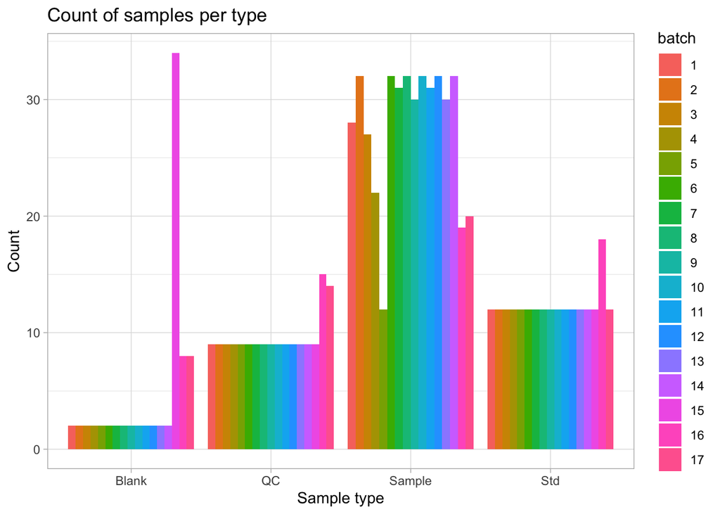

```r
ggsave(file.path(descriptive_plots_dir, "samples_per_type.pdf"), samples_per_type)
samples_per_type
```

### Samples per batch and screen group

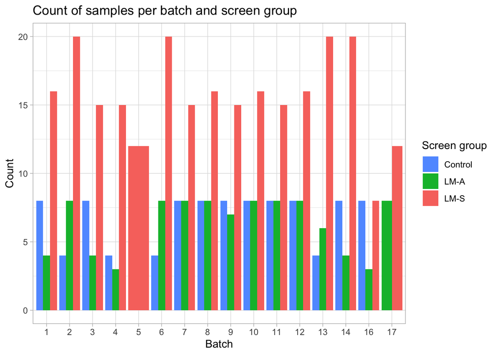

```r
ggsave(file.path(descriptive_plots_dir, "samples_per_batch_and_screen_group.pdf"), samples_per_batch_and_screen_group)
samples_per_batch_and_screen_group
```

### Samples per batch, time point, and screening group

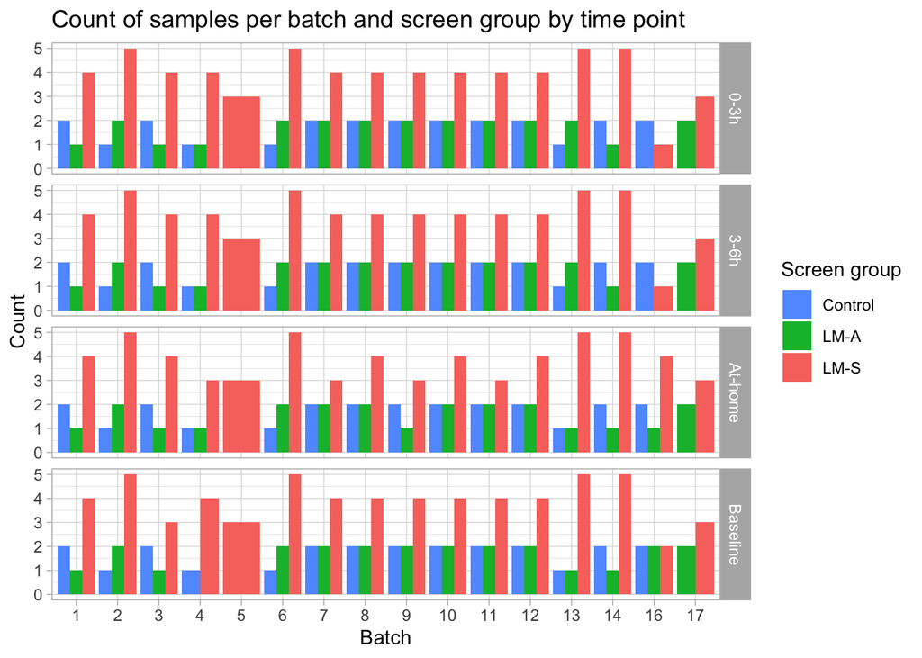

```r
ggsave(file.path(descriptive_plots_dir, "samples_per_batch_and_screen_group_and_timepoint.pdf"), samples_per_batch_and_screen_group_and_timepoint)
samples_per_batch_and_screen_group_and_timepoint
```

### Samples per batch, screen group, and treatment

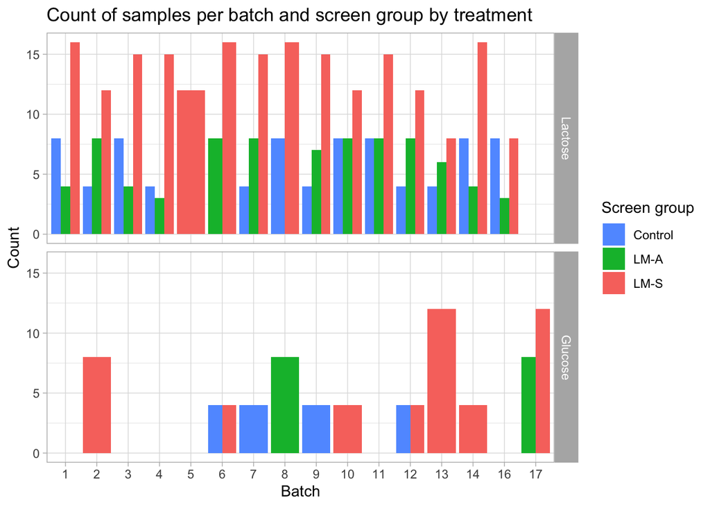

```r
ggsave(file.path(descriptive_plots_dir, "samples_per_batch_and_screen_group_and_treatment.pdf"), samples_per_batch_and_screen_group_and_treatment)
samples_per_batch_and_screen_group_and_treatment
```

## First quality check

As a first check, we will plot the distribution of the data for the different QC samples, coloring by batch to see if there are any clear differences.

```r
response_colnames = c(
    "1,4-Galactonolactone Resp.",
    "Galactose Pk1 Resp.",
    "Galactose Pk2 Resp.",
    "Galactitol Resp.",
    "1,5-Galactonolactone Resp.",
    "Galactonate Resp.",
    "Lactose Pk1 Resp.",
    "Lactose Pk2 Resp.",
    "IStd Xylose Resp."
)

distribution_before_norm = data %>%
  filter(Type == "QC") %>%
  select(all_of(c("batch", "Type", response_colnames))) %>%
  pivot_longer(!c("batch", "Type"), names_to = "metabolite", values_to = "intensity") %>%
  mutate(logint = log(intensity + 1)) %>%
  ggplot(aes(x = logint, color = batch)) +
    geom_density() +
    ggtitle("Before normalization with internal standard") +
    xlab("log(Intensity)") +
    ylab("Density") +
    theme_light() +
    facet_grid(metabolite ~ ., scales = "free_y")
```

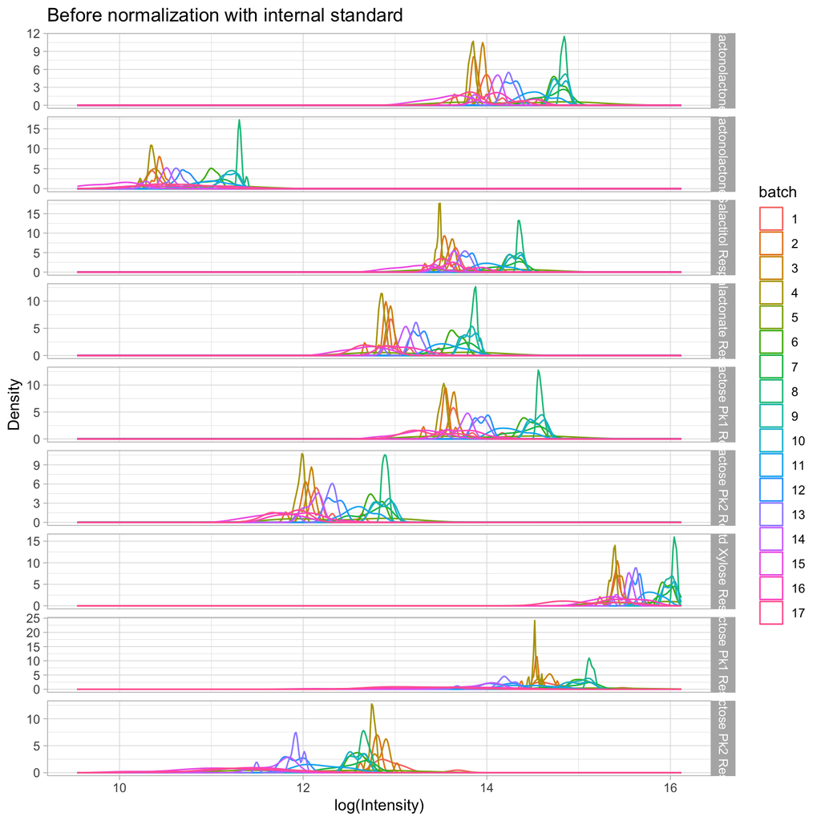

```r
ggsave(file.path(qc_plots_dir, "1_distribution_before_norm.pdf"), distribution_before_norm)
distribution_before_norm
```

We seem to have 2-3 main groups of batches, so we will need to account for that. Let’s keep that in mind when we look at the intensity of the internal standard (Xylose) over injection order.

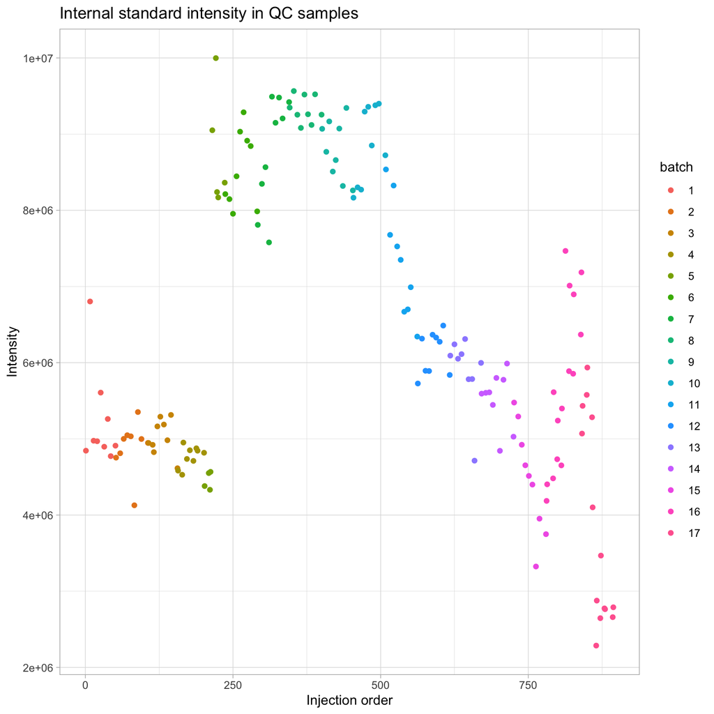

```r
standard_data = data %>%
  select(`IStd Xylose Resp.`, injection_order, batch, Type) %>%
  mutate(order = order(injection_order))

standard_drift = standard_data %>% filter(Type == "QC") %>%
  ggplot(aes(x = order, y = `IStd Xylose Resp.`, color = batch)) +
    geom_point() +
    xlab("Injection order") +
    ylab("Intensity") +
    ggtitle("Internal standard intensity in QC samples") +
    # facet_grid(Type ~ ., scales = "free_y") +
    theme_light()

ggsave(file.path(qc_plots_dir, "istd_drift.pdf"), standard_drift)
standard_drift
```

We see clear batch effects when focusing on the QC row. More specifically, we see:

We can also look at the target compound intensities in the QC samples:

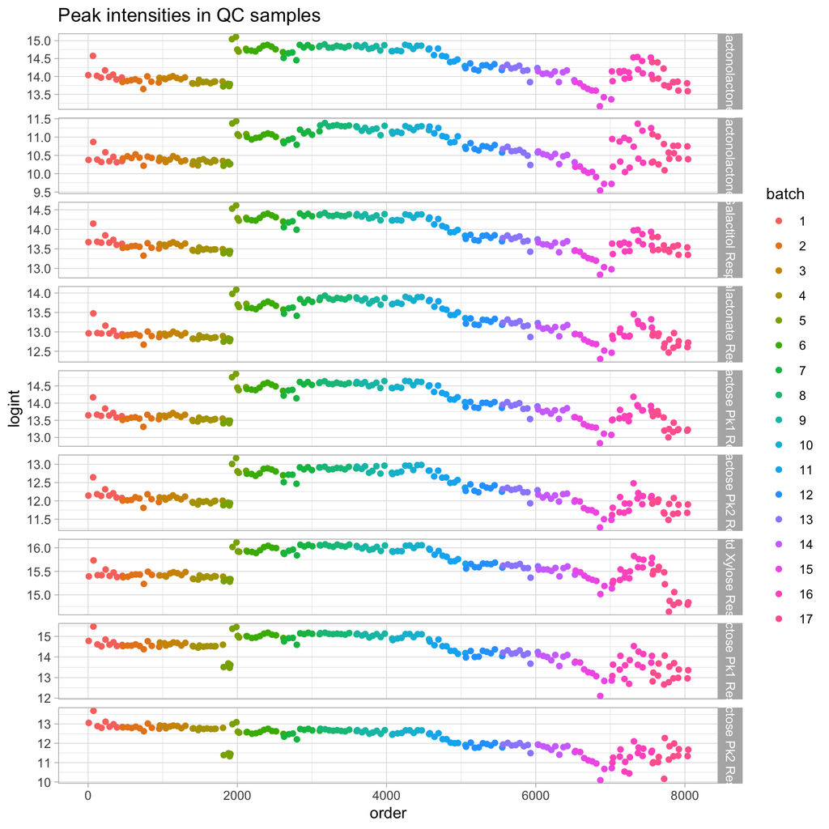

```r
compounds_drift = data %>%
  select(all_of(c("Type", "batch", "injection_order", response_colnames))) %>%
  pivot_longer(
    !c("Type", "batch", "injection_order"),
    names_to = "metabolite",
    values_to = "intensity"
  ) %>%
  mutate(
    order = order(injection_order),
    logint = log(intensity + 1)
  ) %>%
  filter(Type == "QC") %>%
  ggplot(aes(x = order, y = logint, color = batch)) +
    geom_point() +
    ggtitle("Peak intensities in QC samples") +
    facet_grid(metabolite ~ ., scales = "free_y") +
    theme_light()

ggsave(file.path(qc_plots_dir, "compounds_drift.pdf"), compounds_drift)
compounds_drift
```

While most target peaks show the same trend as Xylose, the lactose peaks seem to be a bit different. More specifically, we see:

- In all non-lactose peaks, intensities behave like Xylose.
- In both lactose peaks, intensities go down at the beginning of batch 5 followed by jumping back up. In addition, lactose peak 1 stays higher than batches 1-4, while lactose peak 2 goes back to similar intensities. These observations are important, as this implies that normalizing through dividing by the Xylose value will affect these peaks differently. However, if we make sure that we use the correct quantification curves for each sample, we should be able to mitigate this effect.
- Again, the last two batches behave differently due to having been run quite later.

Altogether, these observations suggest that we should manually assign each sample to its most representative standard curve to make sure we remove most of these effects at the quantification step.

## Normalization using the internal standard (Xylose)

We will first normalize the data using the internal standard. Each metabolite value for each sample is divided by its corresponding Xylose value. This allows us to control variability coming from changes in instrument sensitivity through time. Since the concentration of Xylose is the same across all runs, we are essentially changing the response values to their intensities relative to the Xylose intensity.

```r
colnames_to_divide = c(
    "1,4-Galactonolactone Resp.",
    "Galactose Pk1 Resp.",
    "Galactose Pk2 Resp.",
    "Galactitol Resp.",
    "1,5-Galactonolactone Resp.",
    "Galactonate Resp.",
    "Lactose Pk1 Resp.",
    "Lactose Pk2 Resp.",
    "IStd Xylose Resp."
)
columns_to_divide = which(
  colnames(data) %in% colnames_to_divide
)

colname_divisor_column = "IStd Xylose Resp."
divisor_column = which(colnames(data) %in% colname_divisor_column) # Column with areas under the curve of internal standard

data_norm = data %>% #Division by internal standard and correction for resulting small numbers
  mutate(
    across(
        .cols = (columns_to_divide),
        ~ . / data[[divisor_column]]
    ) * 1000000)

write.table(
  data_norm,
  file.path(raw_results_dir, "3_internal_standard_normalized.tsv"),
  sep = "\t",
  col.names = TRUE,
  row.names = FALSE,
  quote = FALSE
)
```

```r
paged_table(data_norm)
```

| Name | Data File | Type | Acq. Date-Time | IStd Xylose RT | IStd Xylose Resp. | IStd Fructose RT | IStd Fructose Resp. | 1,4-Galactonolactone RT | 1,4-Galactonolactone Resp. | Galactose Pk1 RT | Galactose Pk1 Resp. | Galactose Pk2 RT | Galactose Pk2 Resp. | Galactitol RT | Galactitol Resp. | 1,5-Galactonolactone RT | 1,5-Galactonolactone Resp. | Galactonate RT | Galactonate Resp. | Lactose Pk1 RT | Lactose Pk1 Resp. | Lactose Pk2 RT | Lactose Pk2 Resp. | batch | injection_order |
| --- | --- | --- | --- | --- | --- | --- | --- | --- | --- | --- | --- | --- | --- | --- | --- | --- | --- | --- | --- | --- | --- | --- | --- | --- | --- |
| QC1a | 26022402_QC1a.D | QC | 46077.7187984259 | 24.0370833333333 | 1e+06 | 28.660633333333301 | 5096440.0 | 28.770883333333298 | 2.574608e+05 | 29.043233333333301 | 1.741959e+05 | 29.438800000000001 | 3.882317e+04 | 30.0224166666667 | 1.788603e+05 | 30.223433333333301 | 6622.49554 | 31.092383333333299 | 8.805185e+04 | 42.797150000000002 | 5.424866e+05 | 43.024099999999997 | 9.654752e+04 | 1 | 26022402 |
| Std_0_1 | 26022403_Std_0.D | Std | 46077.7713854514 | 24.0370666666667 | 1e+06 | 28.660616666666701 | 5443892.8 | 28.770849999999999 | 2.606839e+05 | 29.043216666666702 | 1.745152e+05 | 29.438783333333301 | 3.952767e+04 | 30.022400000000001 | 1.825233e+05 | 30.223416666666701 | 6505.66806 | 31.09235 | 8.975980e+04 | 42.797133333333299 | 5.296603e+05 | 43.024083333333301 | 9.333922e+04 | 1 | 26022403 |
| Std_1_1 | 26022404_Std_1.D | Std | 46077.823945463002 | 24.0371666666667 | 1e+06 | 28.660716666666701 | 4979457.5 | 28.770949999999999 | 4.253219e+05 | 29.043299999999999 | 3.589023e+05 | 29.438866666666701 | 7.690116e+04 | 30.015999999999998 | 2.200276e+05 | 30.223500000000001 | 9325.79396 | 31.092449999999999 | 1.679824e+05 | 42.797216666666699 | 7.390988e+05 | 43.024183333333298 | 1.245520e+05 | 1 | 26022404 |
| Std_2_1 | 26022405_Std_2.D | Std | 46077.876524629602 | 24.036899999999999 | 1e+06 | 28.660450000000001 | 5106024.3 | 28.770683333333299 | 5.162858e+05 | 29.043050000000001 | 4.289916e+05 | 29.438600000000001 | 8.776819e+04 | 30.015733333333301 | 2.503663e+05 | 30.22325 | 9831.02844 | 31.092183333333299 | 2.071929e+05 | 42.803449999999998 | 8.520801e+05 | 43.0239166666667 | 1.401871e+05 | 1 | 26022405 |
| Std_3_1 | 26022406_Std_3.D | Std | 46077.929120046298 | 24.036933333333302 | 1e+06 | 28.6604833333333 | 5481089.0 | 28.7707333333333 | 6.374093e+05 | 29.049566666666699 | 5.208534e+05 | 29.438649999999999 | 1.019103e+05 | 30.022266666666699 | 2.900319e+05 | 30.216799999999999 | 12117.31287 | 31.092233333333301 | 2.619676e+05 | 42.803483333333297 | 1.221380e+06 | 43.030450000000002 | 1.921263e+05 | 1 | 26022406 |
| Std_4_1 | 26022407_Std_4.D | Std | 46077.981694780101 | 24.037183333333299 | 1e+06 | 28.660733333333301 | 5018190.8 | 28.777450000000002 | 8.539907e+05 | 29.0498166666667 | 7.779377e+05 | 29.438883333333301 | 1.451344e+05 | 30.022500000000001 | 3.467588e+05 | 30.2235333333333 | 15607.71389 | 31.092466666666699 | 3.682856e+05 | 42.803733333333298 | 1.431736e+06 | 43.0242 | 2.255683e+05 | 1 | 26022407 |
| Std_5_1 | 26022408_Std_5.D | Std | 46078.034282673601 | 24.0370666666667 | 1e+06 | 28.660616666666701 | 5367718.3 | 28.777333333333299 | 1.122578e+06 | 29.049700000000001 | 1.044665e+06 | 29.445250000000001 | 1.950762e+05 | 30.022383333333298 | 4.122862e+05 | 30.223416666666701 | 18669.41091 | 31.0988333333333 | 5.052696e+05 | 42.803616666666699 | 1.925454e+06 | 43.030566666666701 | 3.041503e+05 | 1 | 26022408 |
| QC1b | 26022409_QC1b.D | QC | 46078.086838483803 | 24.043533333333301 | 1e+06 | 28.667066666666699 | 7415589.3 | 28.7773166666667 | 3.147938e+05 | 29.049666666666699 | 2.092265e+05 | 29.445233333333299 | 4.557141e+04 | 30.022366666666699 | 2.045353e+05 | 30.229866666666702 | 7697.14452 | 31.092333333333301 | 1.046511e+05 | 42.8035833333333 | 7.755405e+05 | 43.030549999999998 | 1.286386e+05 | 1 | 26022409 |
| Blank1a | 26022410_Blank1a.D | Blank | 46078.139441631902 | 24.037016666666698 | 1e+06 | 28.6605666666667 | 7347293.0 | 28.861599999999999 | 0.000000e+00 | 29.166366666666701 | 0.000000e+00 | 29.166366666666701 | 0.000000e+00 | 29.9445333333333 | 0.000000e+00 | 30.100166666666698 | 0.00000 | 31.098800000000001 | 0.000000e+00 | 42.881383333333297 | 0.000000e+00 | 42.881383333333297 | 0.000000e+00 | 1 | 26022410 |
| 113_2_A_BL | 26022411_113_2_A_BL.D | Sample | 46078.192043171301 | 24.043500000000002 | 1e+06 | 28.66705 | 6843916.5 | 28.777283333333301 | 2.808971e+05 | 29.043150000000001 | 2.038919e+04 | 29.458166666666699 | 1.535105e+03 | 30.0288166666667 | 8.262800e+04 | 30.236316666666699 | 10502.41718 | 31.092300000000002 | 7.745787e+04 | 42.797066666666701 | 5.181302e+04 | 43.0110666666667 | 1.915580e+04 | 1 | 26022411 |

[output cut: 884 more lines]

We can check how the distributions have changed after the normalization using the internal standard.

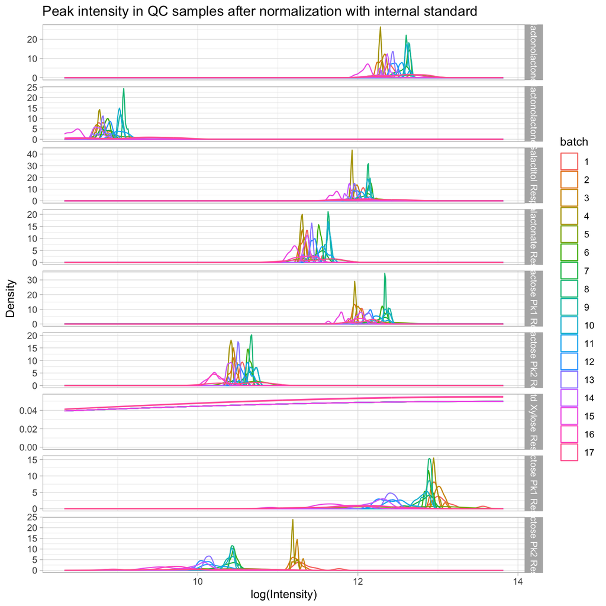

```r
distribution_after_norm = data_norm %>%
  filter(Type == "QC") %>%
  select(all_of(c("batch", "Type", colnames_to_divide, colname_divisor_column))) %>%
  pivot_longer(!c("batch", "Type"), names_to = "metabolite", values_to = "intensity") %>%
  mutate(logint = log(intensity + 1)) %>%
  ggplot(aes(x = logint, color = batch)) +
    geom_density() +
    ggtitle("Peak intensity in QC samples after normalization with internal standard") +
    xlab("log(Intensity)") +
    ylab("Density") +
    theme_light() +
    facet_grid(metabolite ~ ., scales = "free_y")

ggsave(file.path(qc_plots_dir, "2_distribution_after_norm.pdf"), distribution_after_norm)
distribution_after_norm
```

We see that batch effects are still visible. We can also check the drift of the targeted metabolites before and after normalization to see how it worked.

```r
drift_before_norm = data %>%
  select(c(batch, injection_order, Type, colnames_to_divide)) %>%
  mutate(order = order(injection_order, decreasing = FALSE)) %>%
  pivot_longer(!c("batch", "order", "injection_order", "Type"), names_to = "metabolite", values_to = "intensity") %>%
  mutate(logint = log(intensity + 1)) %>%
  ggplot(aes(x = order, y = logint, color = batch, group = batch)) +
    geom_line() +
    ggtitle("Before internal standard normalization") +
    facet_grid(metabolite ~ Type, scales = "free_y") +
    theme_light()

drift_after_norm = data_norm %>%
  select(c(batch, injection_order, Type, colnames_to_divide)) %>%
  mutate(order = order(injection_order, decreasing = FALSE)) %>%
  pivot_longer(!c("batch", "order", "injection_order", "Type"), names_to = "metabolite", values_to = "intensity") %>%
  mutate(logint = log(intensity + 1)) %>%
  ggplot(aes(x = order, y = logint, color = batch, group = batch)) +
    geom_line() +
    ggtitle("After internal standard normalization") +
    facet_grid(metabolite ~ Type, scales = "free_y") +
    theme_light()
```

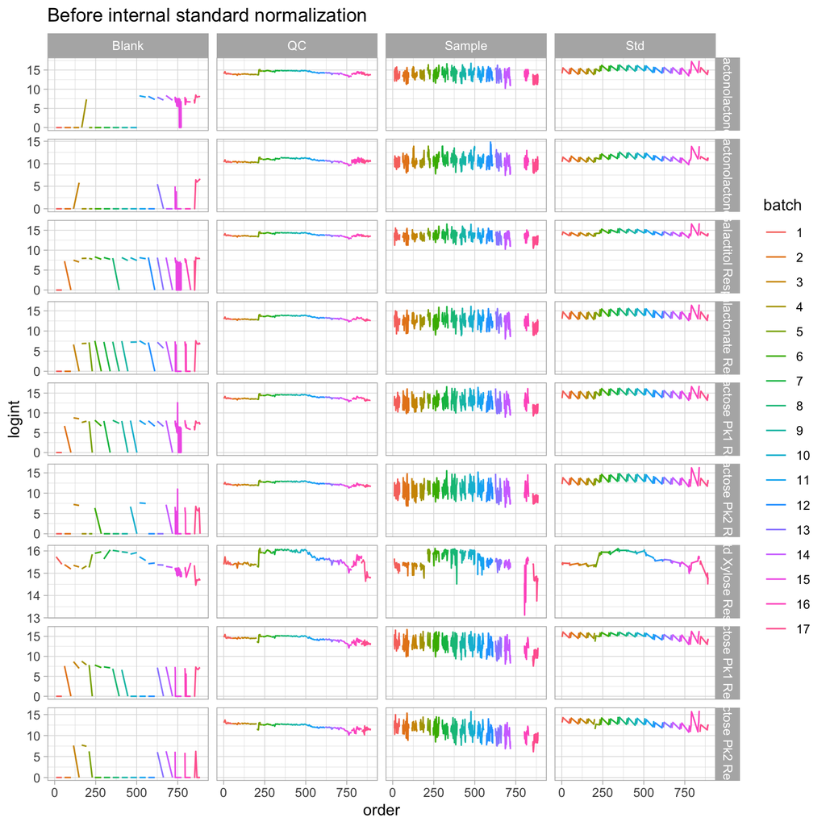

```r
ggsave(file.path(qc_plots_dir, "drifts_before_norm.pdf"), drift_before_norm)
ggsave(file.path(qc_plots_dir, "drifts_after_norm.pdf"), drift_after_norm)
drift_before_norm
```

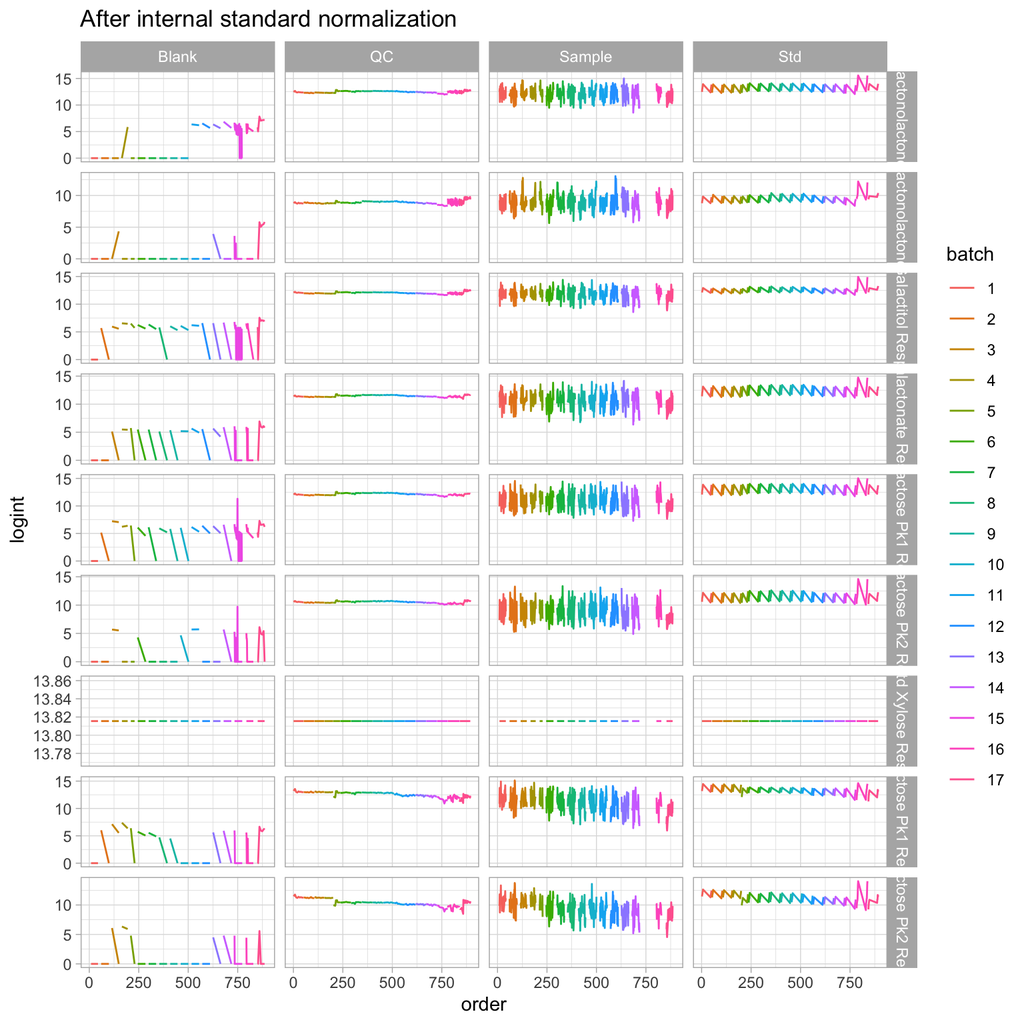

```r
drift_after_norm
```

If we focus on the QC and Std columns, we can see how the values are much more stable after the normalization. However, if we compare the two we see again that something happened in the middle of batch 5. I believe this is still observed after normalization, where we see that the beginning and end of batch 5 are slightly different.

In addition, the first and second standards for batches 4 and 5 show some slight differences. Once again, this suggests it may be better to quantify using a sample’s closest standard.

## Blank subtraction

- Computes each sample’s closest blank.
- For each metabolite in each sample, it subtracts the blank measurement. When this subtraction results in a value < 0, the result is returned as 0.

```r
blank_data = data_norm %>%
  filter(Type == "Blank") %>%
  select(all_of(c("batch", "injection_order", "Name", response_colnames)))
colnames(blank_data)[4:ncol(blank_data)] = paste0("blank_", colnames(blank_data)[4:ncol(blank_data)])

measurement_to_blank_mapping = data %>%
  filter(Type != "Blank") %>%
  select(Name, injection_order)

measurement_to_blank_mapping$corresponding_blank = sapply(measurement_to_blank_mapping$injection_order, function(x) {
  diffs = abs(x - blank_data$injection_order)
  closest_blank = blank_data$Name[which.min(diffs)]
  return(closest_blank)
})

measurement_to_blank_mapping = measurement_to_blank_mapping %>%
  inner_join(blank_data, by = join_by("corresponding_blank" == "Name"))

col_idx_to_keep = c(
  grep("Name", colnames(measurement_to_blank_mapping)),
  grep("corresponding_blank", colnames(measurement_to_blank_mapping)),
  grep("batch", colnames(measurement_to_blank_mapping)),
  grep("blank_", colnames(measurement_to_blank_mapping))
)

measurement_to_blank_mapping = measurement_to_blank_mapping[, col_idx_to_keep]

measurement_to_blank_mapping$join_col = paste0(measurement_to_blank_mapping$batch, "-", measurement_to_blank_mapping$Name)

blank_corrected = data_norm %>%
  mutate(
    join_col = paste0(batch, "-", Name)
  ) %>%
  inner_join(measurement_to_blank_mapping, by = "join_col") %>%
  mutate(
    `1,4-Galactonolactone Resp.` = ifelse(
      `1,4-Galactonolactone Resp.` - `blank_1,4-Galactonolactone Resp.` < 0,
      0,
      `1,4-Galactonolactone Resp.` - `blank_1,4-Galactonolactone Resp.`
    ),
    `Galactose Pk1 Resp.` = ifelse(
      `Galactose Pk1 Resp.` - `blank_Galactose Pk1 Resp.` < 0,
      0,
      `Galactose Pk1 Resp.` - `blank_Galactose Pk1 Resp.`
    ),
    `Galactose Pk2 Resp.` = ifelse(
      `Galactose Pk2 Resp.` - `blank_Galactose Pk2 Resp.` < 0,
      0,
      `Galactose Pk2 Resp.` - `blank_Galactose Pk2 Resp.`
    ),
    `Galactitol Resp.` = ifelse(
      `Galactitol Resp.` - `blank_Galactitol Resp.` < 0,
      0,
      `Galactitol Resp.` - `blank_Galactitol Resp.`
    ),
    `1,5-Galactonolactone Resp.` = ifelse(
      `1,5-Galactonolactone Resp.` - `blank_1,5-Galactonolactone Resp.` < 0,
      0,
      `1,5-Galactonolactone Resp.` - `blank_1,5-Galactonolactone Resp.`
    ),
    `Galactonate Resp.` = ifelse(
      `Galactonate Resp.` - `blank_Galactonate Resp.` < 0,
      0,
      `Galactonate Resp.` - `blank_Galactonate Resp.`
    ),
    `Lactose Pk1 Resp.` = ifelse(
      `Lactose Pk1 Resp.` - `blank_Lactose Pk1 Resp.` < 0,
      0,
      `Lactose Pk1 Resp.` - `blank_Lactose Pk1 Resp.`
    ),
    `Lactose Pk2 Resp.` = ifelse(
      `Lactose Pk2 Resp.` - `blank_Lactose Pk2 Resp.` < 0,
      0,
      `Lactose Pk2 Resp.` - `blank_Lactose Pk2 Resp.`
    )
  ) %>%
  select(Name.x, Type, batch.x, injection_order, `IStd Xylose Resp.`, `IStd Fructose Resp.`, `1,4-Galactonolactone Resp.`, `Galactose Pk1 Resp.`, `Galactose Pk2 Resp.`, `Galactitol Resp.`, `1,5-Galactonolactone Resp.`, `Galactonate Resp.`, `Lactose Pk1 Resp.`, `Lactose Pk2 Resp.`) %>%
  rename(
    Name = Name.x,
    batch = batch.x
  )

write.table(
  blank_corrected,
  file.path(raw_results_dir, "4_blank_corrected.tsv"),
  sep = "\t",
  col.names = TRUE,
  row.names = FALSE,
  quote = FALSE
)
```

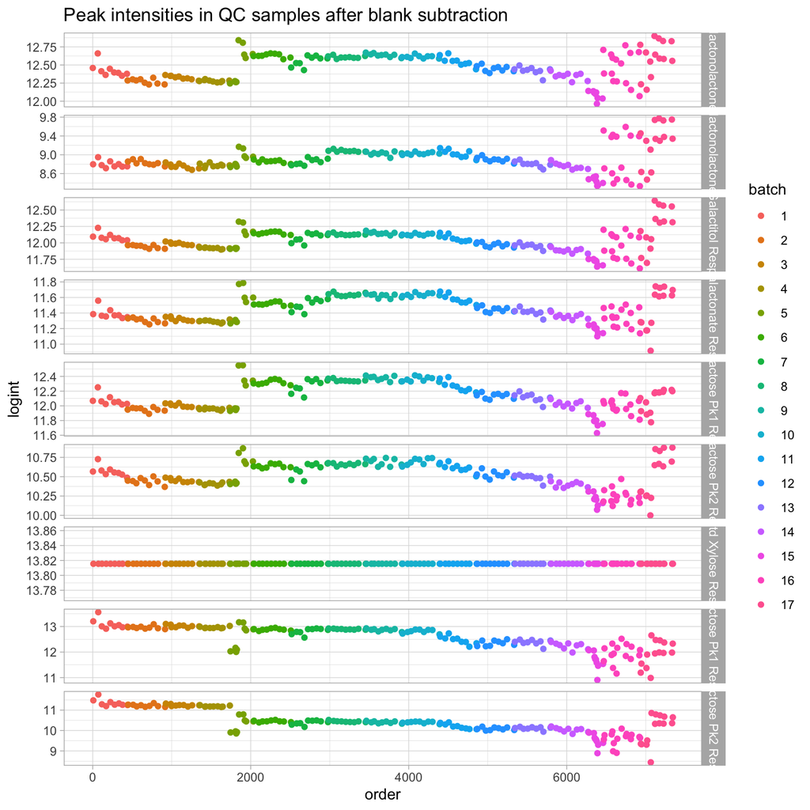

```r
blank_corrected_drift = blank_corrected %>%
  select(all_of(c("Type", "batch", "injection_order", response_colnames))) %>%
  pivot_longer(
    !c("Type", "batch", "injection_order"),
    names_to = "metabolite",
    values_to = "intensity"
  ) %>%
  mutate(
    order = order(injection_order),
    logint = log(intensity + 1)
  ) %>%
  filter(Type == "QC") %>%
  ggplot(aes(x = order, y = logint, color = batch)) +
    geom_point() +
    ggtitle("Peak intensities in QC samples after blank subtraction") +
    facet_grid(metabolite ~ ., scales = "free_y") +
    theme_light()

ggsave(file.path(qc_plots_dir, "blank_corrected_drifts.pdf"), blank_corrected_drift)
blank_corrected_drift
```

While we do not see a major difference, some of the variation coming from the blank samples should now have been taken care of.

## Aggregation of metabolite peaks

The next step is to aggregate the metabolite peaks.

```r
data_norm_agg = blank_corrected %>%
  mutate(
    galactose_ion_area = `Galactose Pk1 Resp.` + `Galactose Pk2 Resp.`,
    lactose_ion_area = `Lactose Pk1 Resp.` + `Lactose Pk2 Resp.`,
    galactitol_ion_area = `Galactitol Resp.`,
    galactonate_ion_area = (`Galactonate Resp.`/8502*95655) + (`1,4-Galactonolactone Resp.`/9999*66940) + (`1,5-Galactonolactone Resp.`/4861*74758)
  ) %>%
  select(
    all_of(
        c(
            "Type",
            "batch",
            "Name",
            "injection_order",
            "galactose_ion_area",
            "lactose_ion_area",
            "galactitol_ion_area",
            "galactonate_ion_area"
        )
    )
  )

write.table(
  data_norm_agg,
  file.path(raw_results_dir, "5_peak_aggregated.tsv"),
  sep = "\t",
  col.names = TRUE,
  row.names = FALSE,
  quote = FALSE
)
```

```r
paged_table(data_norm_agg)
```

| Type | batch | Name | injection_order | galactose_ion_area | lactose_ion_area | galactitol_ion_area | galactonate_ion_area |
| --- | --- | --- | --- | --- | --- | --- | --- |
| QC | 1 | QC1a | 26022402 | 213019.0310 | 639034.1539 | 178860.317 | 2816124.41 |
| Std | 1 | Std_0_1 | 26022403 | 214042.8702 | 622999.4951 | 182523.253 | 2855121.28 |
| Std | 1 | Std_1_1 | 26022404 | 435803.4383 | 863650.8830 | 220027.629 | 4880762.49 |
| Std | 1 | Std_2_1 | 26022405 | 516759.7693 | 992267.2546 | 250366.287 | 5938658.25 |
| Std | 1 | Std_3_1 | 26022406 | 622763.7408 | 1413506.4788 | 290031.851 | 7400964.75 |
| Std | 1 | Std_4_1 | 26022407 | 923072.0815 | 1657304.4081 | 346758.767 | 10100755.93 |
| Std | 1 | Std_5_1 | 26022408 | 1239740.8675 | 2229604.1588 | 412286.162 | 13487134.37 |
| QC | 1 | QC1b | 26022409 | 254797.8884 | 904179.0885 | 204535.332 | 3403233.01 |
| Sample | 1 | 113_2_A_BL | 26022411 | 21924.2989 | 70968.8227 | 82628.003 | 2913500.65 |
| Sample | 1 | 113_2_A_3-6 | 26022412 | 319219.4397 | 1081788.1973 | 301993.089 | 5251082.23 |

[output cut: 806 more lines]

We can now plot again to see how the data looks after the aggregation.

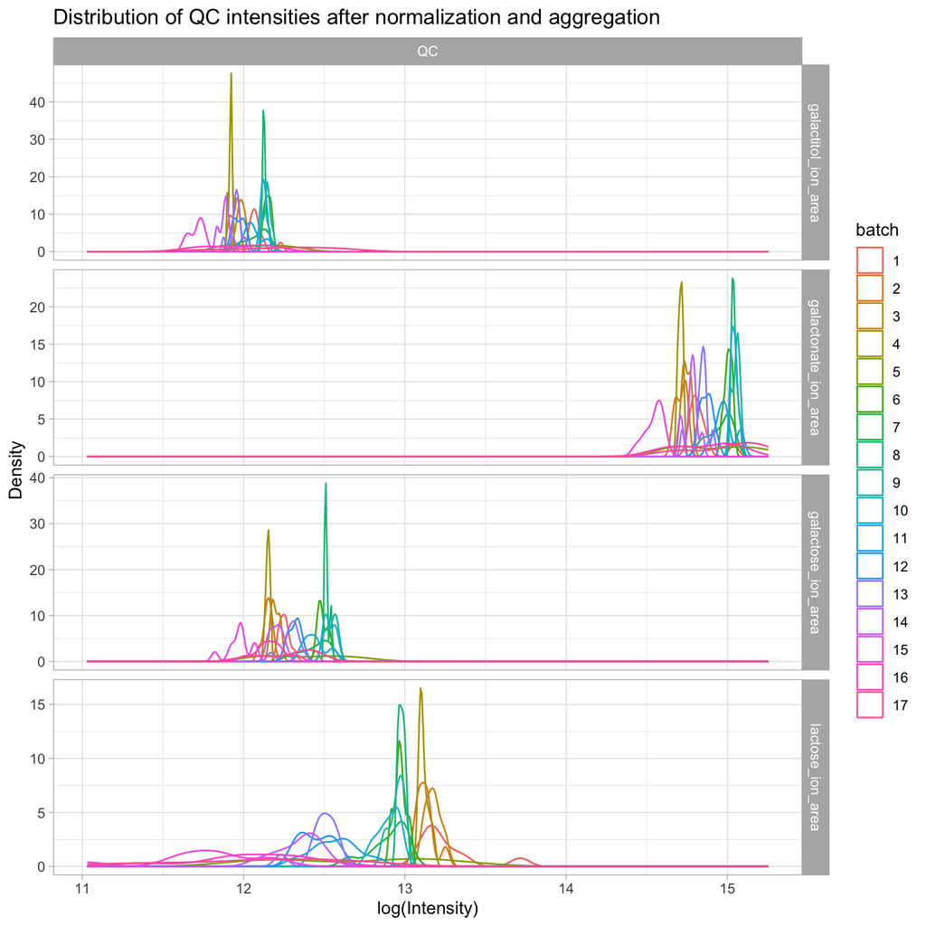

```r
distribution_after_norm_and_agg = data_norm_agg %>%
  filter(Type == "QC") %>%
  select(batch, Name, injection_order, Type, colnames(data_norm_agg)[grep("ion_area", colnames(data_norm_agg))]) %>%
  pivot_longer(!c("Type", "Name", "batch", "injection_order"), names_to = "metabolite", values_to = "intensity") %>%
  mutate(logint = log(intensity + 1)) %>%
  ggplot(aes(x = logint, color = batch)) +
    geom_density() +
    ggtitle("Distribution of QC intensities after normalization and aggregation") +
    xlab("log(Intensity)") +
    ylab("Density") +
    facet_grid(metabolite ~ Type, scales = "free_y") +
    theme_light()

drift_after_norm_agg = data_norm_agg %>%
  filter(Type == "QC") %>%
  select(batch, Name, injection_order, Type, colnames(data_norm_agg)[grep("ion_area", colnames(data_norm_agg))]) %>%
  pivot_longer(!c("Type", "Name", "batch", "injection_order"), names_to = "metabolite", values_to = "intensity") %>%
  mutate(
    logint = log(intensity + 1),
    order = order(injection_order, decreasing = FALSE)
  ) %>%
  ggplot(aes(x = order, y = logint, color = batch)) +
    geom_line() +
    ggtitle("Drift of QC samples after normalization and aggregation") +
    xlab("Injection order") +
    ylab("log(Intensity)") +
    facet_grid(metabolite ~ Type, scales = "free_y") +
    theme_light()


ggsave(file.path(qc_plots_dir, "3_distribution_after_norm_blank_agg.pdf"), distribution_after_norm_and_agg)
ggsave(file.path(qc_plots_dir, "drift_after_norm_blank_agg.pdf"), drift_after_norm_agg)

distribution_after_norm_and_agg
```

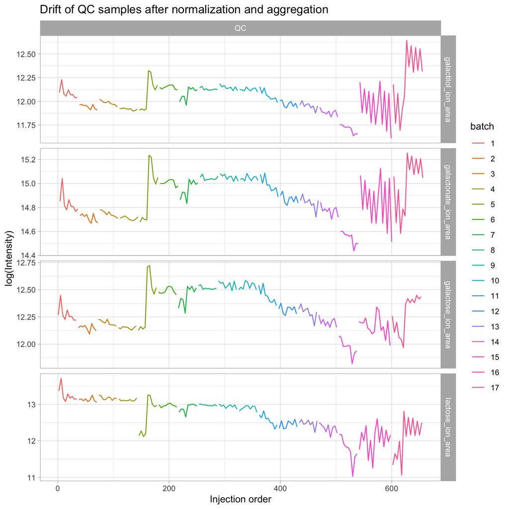

```r
drift_after_norm_agg
```

Things are slowly getting better, but the distributions still look quite different. Also interesting, the aggregation of both lactose peaks seems to bring all lactose batches closer together.

## Quantification using the standard curve for each batch and metabolite

The next step will be to quantify each metabolite’s abundance using the standard curves. The main idea here is that the standards contain the intensity measured by the instrument for a known concentration of a metabolite. We can then train a linear model predicting the concentration of a metabolite using the measured intensity. This model will be used to predict the metabolite concentration for each sample.

In theory, as we are quantifying the data by batch, we may be able to remove some of the batch effects we observed in the previous plots. In addition, since we observed a shift in sensitivities in the middle of batches 5 and 11, we will match each sample with its most similar quantification curve.

First, we will create a mapping from each sample to its most representative quantification curve. For this, we will follow a hybrid approach based on the following figure:

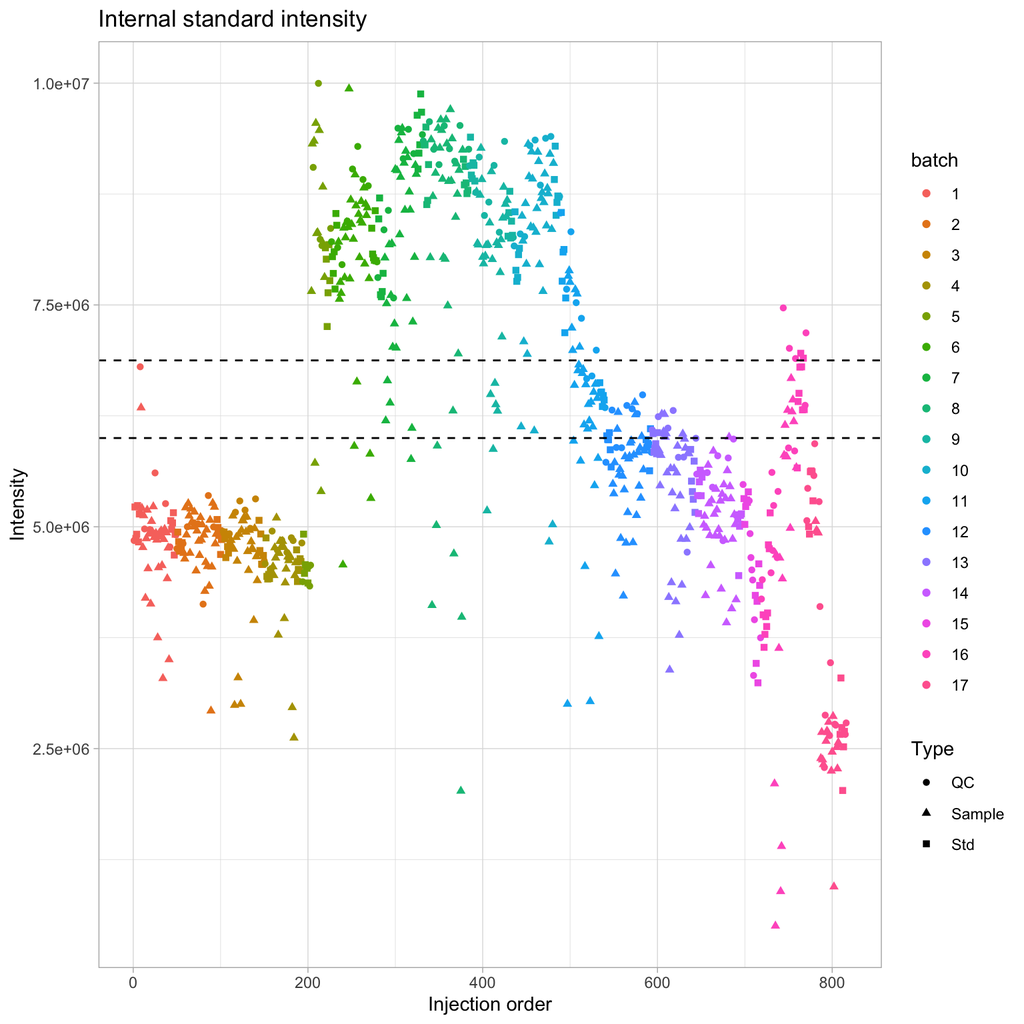

```r
standard_data %>%
  filter(Type != "Blank") %>%
  mutate(order = order(injection_order, decreasing = FALSE)) %>%
  ggplot(aes(x = order, y = `IStd Xylose Resp.`, color = batch, shape = Type)) +
    geom_point() +
    geom_hline(yintercept = 6e+06, linetype = "dashed") +
    geom_hline(yintercept = 6.875e+06, linetype = "dashed") +
    xlab("Injection order") +
    ylab("Intensity") +
    ggtitle("Internal standard intensity") +
    theme_light()
```

```r
# Batches 1-4, 6-10, and 12-15 -> get closest standard
sample_curve_maps_ls = list()
batches = c(1:4, 6:10, 12:15)
i = 1
for (batch_idx in 1:length(batches)) {

  datax = data_norm_agg %>%
    filter(batch == batches[batch_idx])

  sample_curve_maps_ls[[i]] = get_closest_standard(datax)
  i = i + 1

}

# Batch 5 -> done manually based on raw intensity <= 6e+06
sample_curve_maps_ls[[i]] = data %>%
  filter(batch == 5) %>%
  mutate(
    closest_standard = case_when(
      `IStd Xylose Resp.` <= 6e+06 ~ 1,
      `IStd Xylose Resp.` > 6e+06 ~ 2
    )
  ) %>%
  select(batch, Name, closest_standard, injection_order)

i = i + 1
# Batch 11 -> done manually based on raw intensity <= 6.875e+06
sample_curve_maps_ls[[i]] = data %>%
  filter(batch == 11) %>%
  mutate(
    closest_standard = case_when(
      `IStd Xylose Resp.` >= 6.875e+06 ~ 1,
      `IStd Xylose Resp.` < 6.875e+06 ~ 2
    )
  ) %>%
  select(batch, Name, closest_standard, injection_order)

i = i + 1
# Batch 16 -> done manually based on raw intensity <= 5.7e+06
sample_curve_maps_ls[[i]] = data %>%
  filter(batch == 16) %>%
  mutate(
    closest_standard = case_when(
      `IStd Xylose Resp.` <= 5.75e+06 ~ 1,
      `IStd Xylose Resp.` > 5.75e+06 ~ 2
    )
  ) %>%
  select(batch, Name, closest_standard, injection_order)

i = i + 1
# Batch 17 -> done manually based on raw intensity <= 4e+06
sample_curve_maps_ls[[i]] = data %>%
  filter(batch == 17) %>%
  mutate(
    closest_standard = case_when(
      `IStd Xylose Resp.` >= 4e+06 ~ 1,
      `IStd Xylose Resp.` < 4e+06 ~ 2,
    )
  ) %>%
  select(batch, Name, closest_standard, injection_order)

sample_curve_maps = do.call(rbind, sample_curve_maps_ls)

write.table(
  sample_curve_maps,
  file.path(raw_results_dir, "6_sample_curve_maps.tsv"),
  sep = "\t",
  col.names = TRUE,
  row.names = FALSE,
  quote = FALSE
)
```

Just to make sure, we will plot again the drift plot with the information of which quantification curve was selected for each sample:

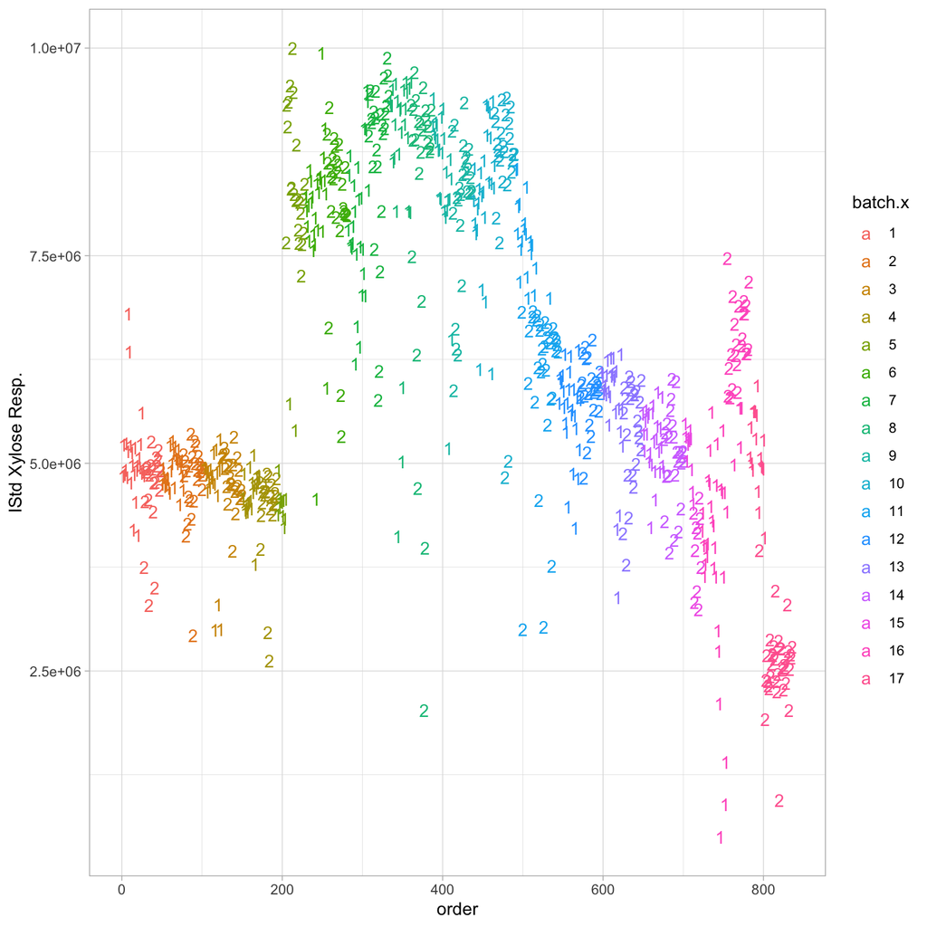

```r
sample_curve_plot = sample_curve_maps %>%
  arrange(injection_order) %>%
  mutate(order = order(injection_order)) %>%
  inner_join(data, by = "injection_order") %>%
  ggplot(aes(x = order, y = `IStd Xylose Resp.`, color = batch.x, shape = Type, label = closest_standard)) +
    geom_text() +
    theme_light()

ggsave(file.path(qc_plots_dir, "sample_to_quant_curve_plot.pdf"), sample_curve_plot)
sample_curve_plot
```

While this works for pretty much all samples, we see that the samples falling between the first and second sub-batches of batches 5 and 11 are a bit off. However, these samples are quite out of range from both quantification curves, and will most likely end up being discarded as outliers. For example, there are some samples with intensity values between 0-2.5e+06. Four of these samples were already reprocessed due to low intensities, which suggests that they indeed had lower levels.

```r
data %>% filter(`IStd Xylose Resp.` < 2.5e+06) %>% pull(Name)
```

```
##  [1] "017_3_A_AH"  "150_3_A_BL"  "077_2_A_BL"  "124_2_A_AH"  "124_2_A_BL"
##  [6] "Blank17d"    "154_3_B_3-6" "154_3_B_BL"  "154_3_B_0-3" "QC17d"
## [11] "Blank17e"    "Blank17f"    "145_3_B_0-3" "145_3_B_3-6" "145_3_B_AH"
## [16] "035_2_B_AH"  "Blank17h"    "Std_3_2"
```

In addition, the lab technician mentioned that some measurements in the quantification standards turned a bit low. Let’s plot the standard curves again to check this:

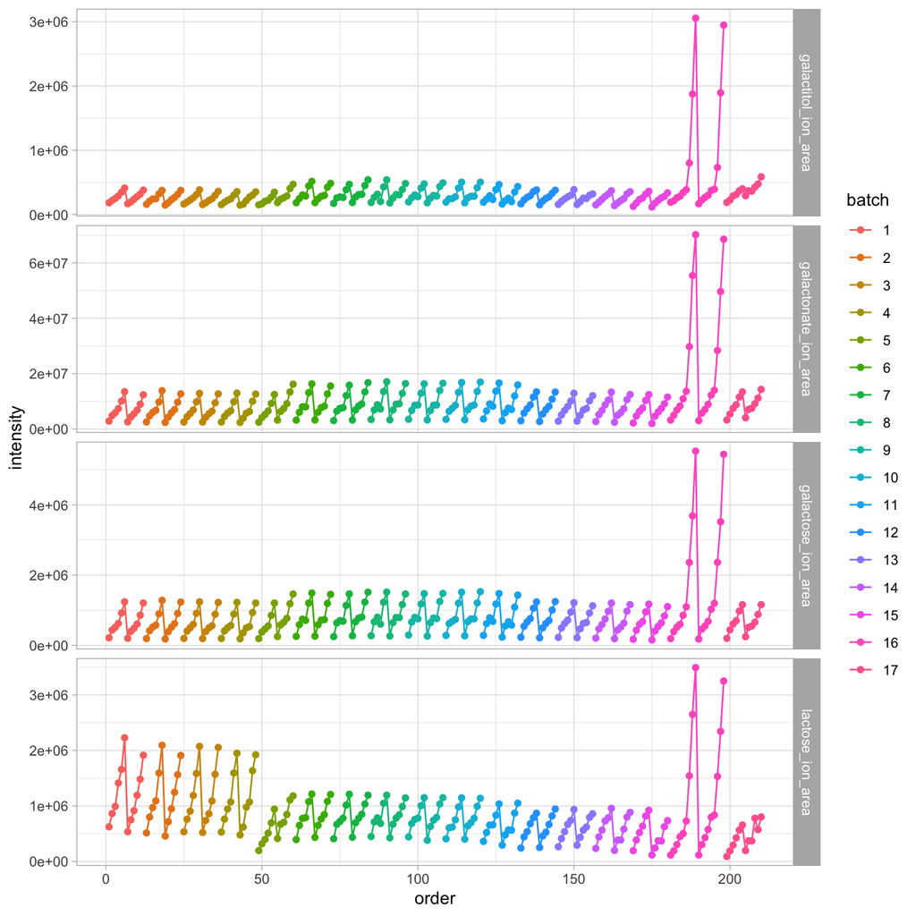

```r
quant_curves_check = data_norm_agg %>%
  filter(Type == "Std") %>%
  select(batch, injection_order, colnames(data_norm_agg)[grep("ion_area", colnames(data_norm_agg))]) %>%
  mutate(
    order = order(injection_order, decreasing = FALSE)
  ) %>%
  pivot_longer(!c("batch", "injection_order", "order"), names_to = "metabolite", values_to = "intensity") %>%
  ggplot(aes(x = order, y = intensity, color = batch, group = batch)) +
    geom_line() +
    geom_point() +
    facet_grid(metabolite ~ ., scales = "free_y") +
    theme_light()

ggsave(file.path(qc_plots_dir, "quantification_curves.pdf"), quant_curves_check)
quant_curves_check
```

The expectation on this plot is to observe an “N” shape for each batch, indicating that the measured intensity increased with the increase in concentration of the quantification standard. While some of the compounds show the expected shape, we see that some cases show a dip in the intensity of standard 3. Since each point within a quantification curve should be higher than its previous one (due to increasing concentration), we will remove standard points where the measured intensity is lower than its preceding one.

We also attempted to add some extra measurements on the quantification curve of the last batch to see if this would help quantify samples on the higher concentration ranges. As we see, the higher concentrations do not result in a linear increase in intensities, meaning that the regression model would struggle to properly quantify samples if we used all points. Therefore, we will skip the extra points and use the same amount of data for all batches.

```r
processed_batches_ls = list()
batches = unique(data_norm_agg$batch)

for (batch_idx in 1:length(batches)) {

  if (batches[batch_idx] == 16) {
    datax = data_norm_agg %>%
      filter(batch == batches[batch_idx]) %>%
      filter(!grepl("Std_[678]", Name))
  } else {
    datax = data_norm_agg %>%
      filter(batch == batches[batch_idx])
  }

  batch_standard_curve_map = sample_curve_maps %>%
    filter(batch == batch_idx)

  datax = datax[order(datax$Type), ] #Std are alphabetically at the end, now known concentrations can be entered

    datax = introduce_known_concentrations(datax, custom_standard_map = batch_standard_curve_map)

    datax = subract_matrix_blanks(datax, custom_standard_map = batch_standard_curve_map)


  #Calculate sample concentrations
  datax = calculate_sample_concentrations(datax, custom_standard_map = batch_standard_curve_map, r2_output_file = file.path(raw_results_dir, "r_squared_results.tsv"))

  #Put data "x" back into batch data AND REPEAT
  processed_batches_ls[[batch_idx]] = datax

}

data_quantified = do.call(rbind, processed_batches_ls) %>%
  rename(
    "injection_order" = "injection_order.x",
    "batch" = "batch.x"
  )

write.table(
  data_quantified,
  file.path(raw_results_dir, "7_quantified_data.tsv"),
  sep = "\t",
  col.names = TRUE,
  row.names = FALSE,
  quote = FALSE
)

write_xlsx(data_quantified, "urine_targeted_gcms_qcs_processed.xlsx")
```

Let’s check up the distribution and drift for the quantified data using the closest standard.

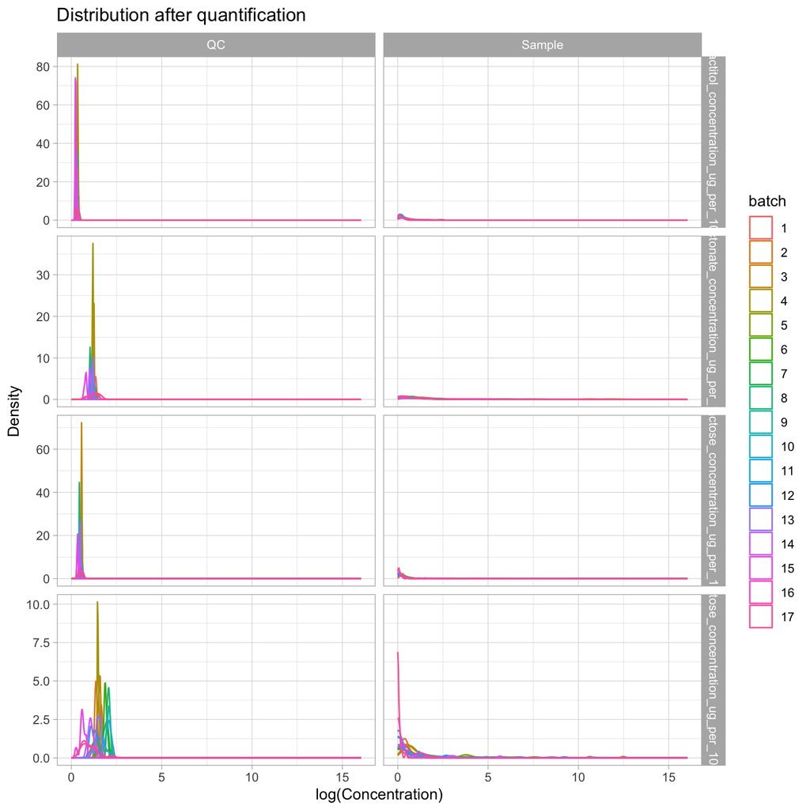

```r
distribution_after_quantification = data_quantified %>%
    filter(Type %in% c("QC", "Sample")) %>%
    select(Type, batch, injection_order, colnames(data_quantified)[grep("_concentration_ug_per_100ul", colnames(data_quantified))]) %>%
    pivot_longer(!c("Type", "batch", "injection_order"), names_to = "metabolite", values_to = "value") %>%
    ggplot(aes(x = value, color = batch)) +
        geom_density() +
        ggtitle("Distribution after quantification") +
        xlab("log(Concentration)") +
        ylab("Density") +
        facet_grid(metabolite ~ Type, scales = "free_y") +
        theme_light()

drift_after_quantification = data_quantified %>%
    filter(Type %in% c("QC", "Sample")) %>%
    mutate(order = order(injection_order, decreasing = FALSE)) %>%
    select(Type, batch, order, colnames(data_quantified)[grep("_concentration_ug_per_100ul", colnames(data_quantified))]) %>%
    pivot_longer(!c("Type", "batch", "order"), names_to = "metabolite", values_to = "value") %>%
    ggplot(aes(x = order, y = value, group = batch, color = batch)) +
        geom_line() +
        facet_grid(metabolite ~ Type, scales = "free_y") +
        theme_light()

ggsave(file.path(qc_plots_dir, "4_distribution_after_quantification.pdf"), distribution_after_quantification)
ggsave(file.path(qc_plots_dir, "drifts_after_quantification.pdf"), drift_after_quantification)

distribution_after_quantification
```

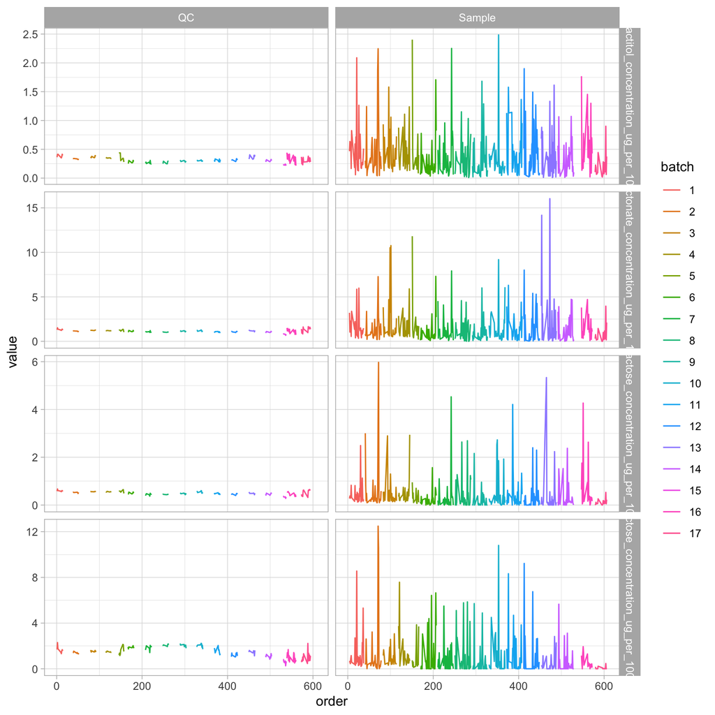

```r
drift_after_quantification
```

The plots above show the distribution and drift after mapping each sample to the most reasonable standard. Overall, it seems the batch effect have been taken care of. However, it is worth noting that we still see a bit of wiggle in the quantified QC samples for lactose and galactitol. I believe the best way to take care of this is to include the batch number as a covariate in our differential analysis.

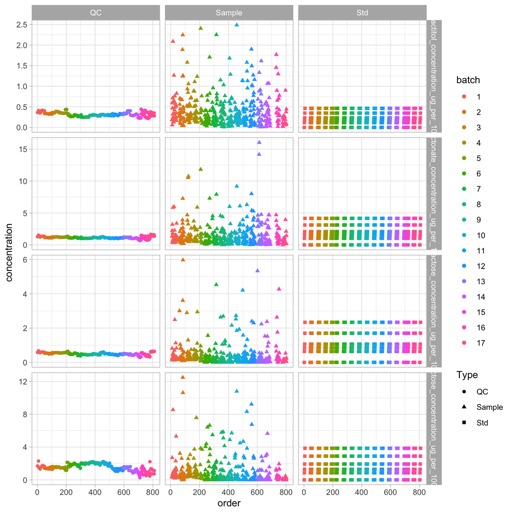

```r
data_quantified %>%
  select(all_of(c("Type", "batch", "injection_order", colnames(data_quantified)[grepl("concentration", colnames(data_quantified))]))) %>%
  arrange(injection_order) %>%
  mutate(order = order(injection_order)) %>%
  pivot_longer(!c("Type", "batch", "injection_order", "order"), names_to = "metabolite", values_to = "concentration") %>%
  ggplot(aes(x = order, y = concentration, color = batch, shape = Type)) +
    geom_point() +
    facet_grid(metabolite ~ Type, scales = "free_y") +
    theme_light()
```

Also just as a check, let’s see how many measured intensities are outside the range of intensities measured in the standards.

```r
standard_ranges = data_quantified %>%
    arrange(injection_order, decreasing = FALSE) %>%
    filter(grepl("Std", Name)) %>%
    # mutate(standard_group = rep(1:7, each = 12)) %>%
    group_by(batch) %>%
    summarise(
        min_galactose = min(galactose_ion_area),
        max_galactose = max(galactose_ion_area),
        min_lactose = min(lactose_ion_area),
        max_lactose = max(lactose_ion_area),
        min_galactitol = min(galactitol_ion_area),
        max_galactitol = max(galactitol_ion_area),
        min_galactonate = min(galactonate_ion_area),
        max_galactonate = max(galactonate_ion_area)
    ) %>%
    pivot_longer(!batch, names_to = "metabolite", values_to = "value") %>%
    separate(metabolite, c("measure", "metabolite"))

midpoints = data_quantified %>%
    filter(grepl("Std", Name)) %>%
    arrange(injection_order, decreasing = FALSE) %>%
    select(injection_order) %>%
    mutate(
        standard_group = rep(1:17, each = 12)
    ) %>%
    group_by(standard_group) %>%
    summarise(midpoint = mean(injection_order))

standard_midpoints = data_quantified %>%
    filter(grepl("Std", Name)) %>%
    arrange(injection_order, decreasing = FALSE) %>%
    select(injection_order) %>%
    mutate(
        standard_group = rep(1:17, each = 12)
    ) %>%
    inner_join(midpoints, by = "standard_group")

df_for_checking = data_quantified %>%
    left_join(standard_midpoints, by = "injection_order")

df_for_checking$closest_standard = sapply(1:nrow(df_for_checking), function(x) {
    which.min(abs(df_for_checking$injection_order[x] - unique(standard_midpoints$midpoint)))
})

ranges_ls = list()
for (group in standard_ranges$batch) {

    current_range = standard_ranges %>%
        filter(batch == group)

    ranges_ls[[group]] = df_for_checking %>%
        filter(!grepl("Std", Name)) %>%
        filter(closest_standard == group) %>%
        select(Name, closest_standard, injection_order, galactose_ion_area, lactose_ion_area, galactitol_ion_area, galactonate_ion_area) %>%
        pivot_longer(!c(Name, injection_order, closest_standard), names_to = "metabolite", values_to = "value") %>%
        mutate(metabolite = gsub("_ion_area", "", metabolite)) %>%
        inner_join(current_range, by = "metabolite") %>%
        mutate(
            in_range = case_when(
                measure == "min" ~ value.x >= value.y,
                measure == "max" ~ value.x <= value.y
            )
        )

}

check_df = do.call(rbind, ranges_ls)
```

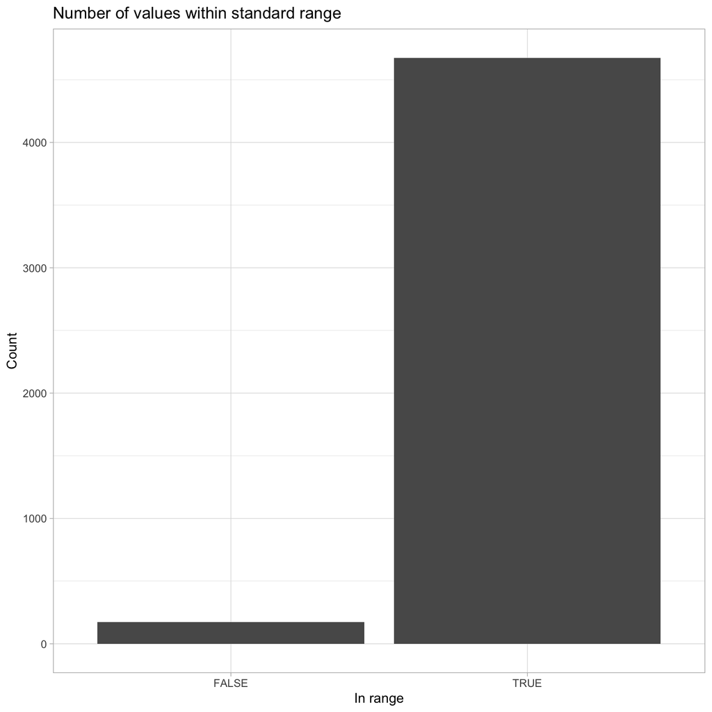

```r
check_df %>%
    select(in_range) %>%
    group_by(in_range) %>%
    summarise(Count = n()) %>%
    ggplot(aes(x = in_range, y = Count)) +
        geom_bar(stat = "identity") +
        ggtitle("Number of values within standard range") +
        xlab("In range") +
        theme_light()
```

Some values are outside the standard ranges. We should keep that in mind in the interpretation.

Finally, we will also plot the distribution of R<sup>2</sup> :

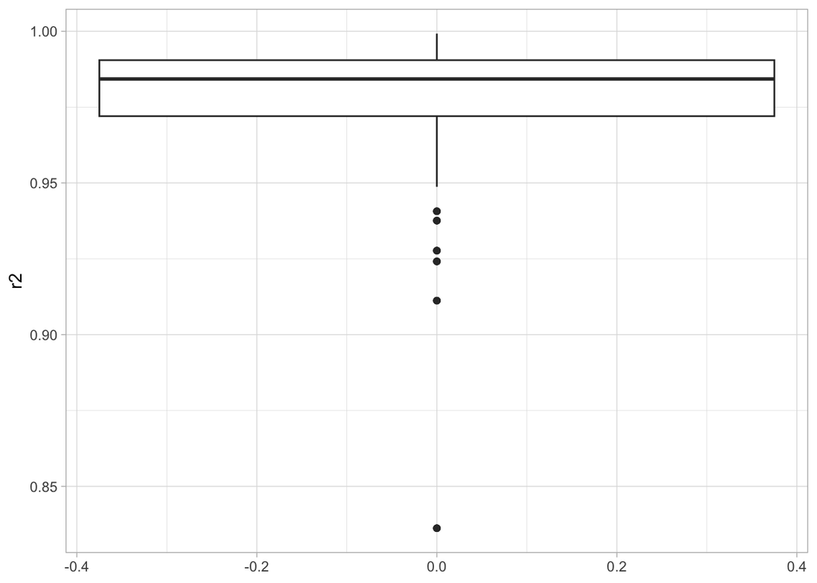

```r
r2s = read.delim(file.path(raw_results_dir, "r_squared_results.tsv"))
r2_plot = ggplot(r2s, aes(y = r2)) +
  geom_boxplot() +
  theme_light()

ggsave(file.path(qc_plots_dir, "r_squared_distribution.pdf"), r2_plot)
r2_plot
```

```r
print(paste0("Mean: ", mean(r2s$r2)))
```

```
## [1] "Mean: 0.978873601451827"
```

```r
print(paste0("SD: ", sd(r2s$r2)))
```

```
## [1] "SD: 0.0200330065378843"
```

```r
print(paste0("Median: ", median(r2s$r2)))
```

```
## [1] "Median: 0.98428231740245"
```

```r
print(paste0("Max: ", max(r2s$r2)))
```

```
## [1] "Max: 0.999235462214531"
```

```r
print(paste0("Min: ", min(r2s$r2)))
```

```
## [1] "Min: 0.836198301189075"
```

## Normalization using urine volume

```r
## Preparation
data_quantified = data_quantified %>%
    mutate(
        # Extract leading digits (can be 1–3 digits or more)
        extracted_digits = str_extract(Name, "^[0-9]+"), #Look for digits at the beginning of the string
        # Create study_id with padded digits to always have 3 digits
        study_id = if_else(
            !is.na(extracted_digits),
            paste0("LB", str_pad(extracted_digits, width = 3, pad = "0")),
            NA_character_
        )
    ) %>%
    left_join(unblinding, by = join_by("study_id" == "study_id_lb"))

# Get REDCap data
redcap_data = read.csv("UrineGCMSAnalysisMetadata_20260430.csv") %>%
  mutate(study_id = gsub("_", "", study_id_lb)) #In this specific extract, first row included explanations for collaborators

# Join with quantified GC-MS data
data_quantified = data_quantified %>%
    left_join(redcap_data, by = "study_id")
```

Next we will normalize the data by using the urine volume.

```r
# Calculate of whole urine volumes under assumption that urine density: 1.020 g/ml
data_quantified = data_quantified %>%
    mutate(
        urine_b2_ml = (int_wt_urine_b2 - int_wt_empty_urine_b2) / 1.02,
        urine_p1_ml = (int_urine_3_00_wt_pool1 - int_urine_wt_empty_pool1) / 1.02,
        urine_p2_ml = (int_urine_6_00_wt_pool2 - int_urine_wt_empty_pool2) / 1.02
    )

# Calculate fluid consumption (water density ~1.00 g/ml)
data_quantified = data_quantified %>%
  mutate(
    water_consumed_b2_ml = 650,
    water_consumed_p1_ml = int_water_wt_full - int_water_wt_3_00,
    water_consumed_p2_ml = int_water_wt_full - int_water_wt_6_00
  )

# Check that urine and water consumption columns survived normalization; re-attach if dropped
urine_water_cols <- c("urine_b2_ml", "urine_p1_ml", "urine_p2_ml",
                       "water_consumed_b2_ml", "water_consumed_p1_ml", "water_consumed_p2_ml")

if (!all(urine_water_cols %in% names(data_quantified))) {
  cat("Some urine/water columns were dropped by normalize_by_urine_volume() - re-attaching.\n")
  data_normalized = data_normalized %>%
    left_join(
      data_quantified %>% dplyr::select(study_id, all_of(urine_water_cols)),
      by = "study_id"
    )
}

# Normalization with whole urine volume
# (ug/100ul)*ml = 10 ug
data_normalized = normalize_by_urine_volume(data_quantified) %>%
  rename(treatment = int_group)

write.table(
  data_normalized,
  file.path(raw_results_dir, "urine_normalized.tsv"),
  sep = "\t",
  col.names = TRUE,
  row.names = FALSE,
  quote = FALSE
)

write_xlsx(data_normalized, "urine_targeted_gcms_data_processed.xlsx")
```

```r
paged_table(data_normalized)
```

| Type | batch | Name | injection_order | galactose_ion_area | lactose_ion_area | galactitol_ion_area | galactonate_ion_area | galactose_concentration_ug_per_100ul | lactose_concentration_ug_per_100ul | galactitol_concentration_ug_per_100ul | galactonate_concentration_ug_per_100ul | batch.y | closest_standard | injection_order.y | extracted_digits | study_id | treatment | study_id_lb | sex | age | height_cm | weight_kg | bmi_calculated | ethnicity_id___1 | ethnicity_id___2 | ethnicity_id___3 | ethnicity_id___4 | ethnicity_id___5 | ethnicity_id___6 | … |
| --- | --- | --- | --- | --- | --- | --- | --- | --- | --- | --- | --- | --- | --- | --- | --- | --- | --- | --- | --- | --- | --- | --- | --- | --- | --- | --- | --- | --- | --- | --- |
| QC | 1 | QC1a | 26022402 | 213019.0310 | 639034.1539 | 178860.317 | 2816124.41 | 0.5787628933 | 1.688278596 | 0.363111885 | 1.29751196 | 1 | 1 | 26022402 | NA | NA | NA | NA | NA | NA | NA | NA | NA | NA | NA | NA | NA | NA | NA | … |
| QC | 1 | QC1b | 26022409 | 254797.8884 | 904179.0885 | 204535.332 | 3403233.01 | 0.6715239785 | 2.295743308 | 0.411154650 | 1.52173542 | 1 | 1 | 26022409 | NA | NA | NA | NA | NA | NA | NA | NA | NA | NA | NA | NA | NA | NA | NA | … |
| QC | 1 | QC1c | 26022415 | 212313.4002 | 525826.7828 | 175879.206 | 2718925.73 | 0.5771961899 | 1.428912965 | 0.357533668 | 1.26039068 | 1 | 1 | 26022415 | NA | NA | NA | NA | NA | NA | NA | NA | NA | NA | NA | NA | NA | NA | NA | … |
| QC | 1 | QC1d | 26022421 | 204268.4290 | 478711.9731 | 172064.986 | 2621054.89 | 0.5593340389 | 1.320969797 | 0.350396548 | 1.22301269 | 1 | 1 | 26022421 | NA | NA | NA | NA | NA | NA | NA | NA | NA | NA | NA | NA | NA | NA | NA | … |
| QC | 1 | QC1e | 26022427 | 222847.8201 | 589902.2007 | 183824.661 | 2854817.74 | 0.6005856333 | 1.575714017 | 0.372401103 | 1.31228939 | 1 | 1 | 26022427 | NA | NA | NA | NA | NA | NA | NA | NA | NA | NA | NA | NA | NA | NA | NA | … |
| QC | 1 | QC1f | 26022433 | 209346.8179 | 524173.8831 | 174424.861 | 2693760.88 | 0.6047043088 | 1.671706494 | 0.414214032 | 1.37100885 | 1 | 2 | 26022433 | NA | NA | NA | NA | NA | NA | NA | NA | NA | NA | NA | NA | NA | NA | NA | … |
| QC | 1 | QC1g | 26022439 | 210016.0048 | 550820.6713 | 174834.191 | 2690839.17 | 0.6062679053 | 1.751779775 | 0.415155236 | 1.36971832 | 1 | 2 | 26022439 | NA | NA | NA | NA | NA | NA | NA | NA | NA | NA | NA | NA | NA | NA | NA | … |
| QC | 1 | QC1h | 26022445 | 203088.9554 | 508073.5863 | 169282.696 | 2586269.00 | 0.5900824281 | 1.623325294 | 0.402390257 | 1.32352925 | 1 | 2 | 26022445 | NA | NA | NA | NA | NA | NA | NA | NA | NA | NA | NA | NA | NA | NA | NA | … |
| QC | 1 | QC1i | 26022456 | 202944.7447 | 516315.7550 | 169295.566 | 2640873.63 | 0.5897454708 | 1.648092913 | 0.402419852 | 1.34764834 | 1 | 2 | 26022456 | NA | NA | NA | NA | NA | NA | NA | NA | NA | NA | NA | NA | NA | NA | NA | … |
| Sample | 1 | 113_2_A_BL | 26022411 | 21924.2989 | 70968.8227 | 82628.003 | 2913500.65 | 0.1544776008 | 0.386803070 | 0.183043190 | 1.33470106 | 1 | 1 | 26022411 | 113 | LB113 | Treatment A | LB_113 | 1 | 24 | 170 | 62.4 | 21.6 | 1 | 0 | 0 | 0 | 0 | 0 | … |

[output cut: 800 more lines]

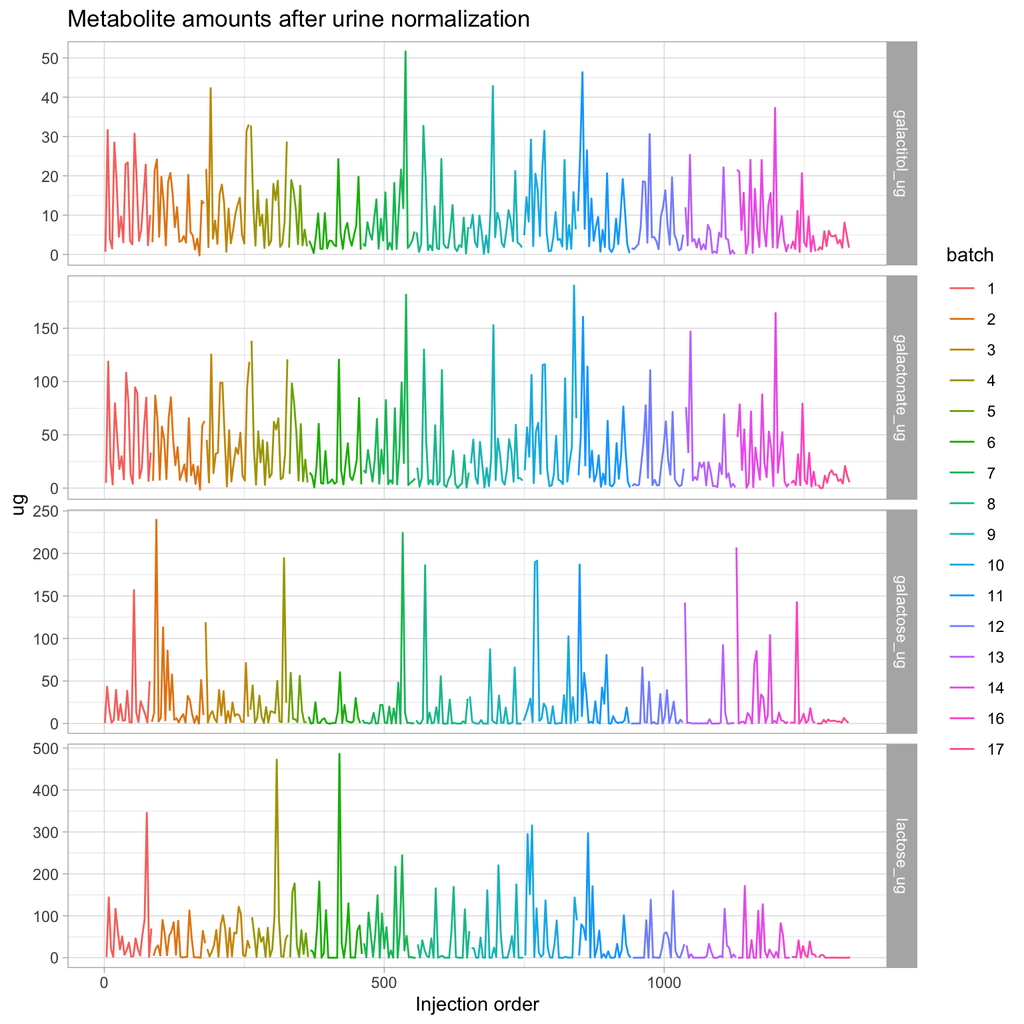

```r
drift_after_urine_norm = data_normalized %>%
  select(batch, Type, Name, injection_order, galactose_ug, galactitol_ug, galactonate_ug, lactose_ug) %>%
  filter(!grepl("_AH", Name)) %>%
  filter(!Type %in% c("QC", "Std")) %>%
  pivot_longer(!c("Name", "batch", "Type", "injection_order"), names_to = "metabolite", values_to = "ug") %>%
  mutate(
     order = order(injection_order, decreasing = FALSE)
  ) %>%
  ggplot(aes(x = order, y = ug, color = batch)) +
  geom_line() +
  xlab("Injection order") +
  ylab("ug") +
  ggtitle("Metabolite amounts after urine normalization") +
  facet_grid(metabolite ~ ., scales = "free_y") +
  theme_light()

ggsave(file.path(qc_plots_dir, "drift_after_urine_norm.pdf"), drift_after_urine_norm)
drift_after_urine_norm
```

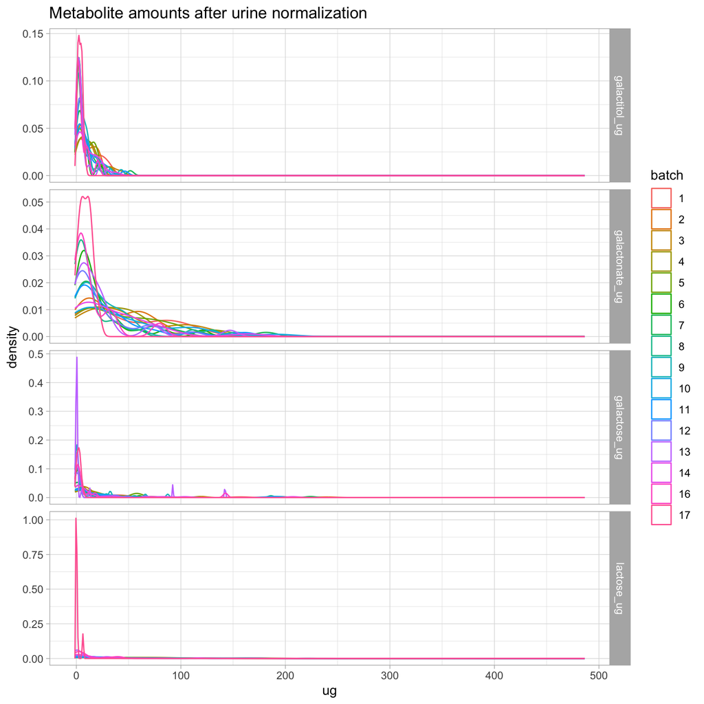

```r
distribution_after_urine_normalization = data_normalized %>%
  filter(Type == "Sample") %>%
  filter(!grepl("_AH", Name)) %>%
    select(batch, Name, injection_order, galactose_ug, lactose_ug, galactitol_ug, galactonate_ug) %>%
    pivot_longer(!c(batch, Name, injection_order), names_to = "metabolite", values_to = "ug") %>%
    ggplot(aes(x = ug, color = batch)) +
      geom_density() +
      ggtitle("Metabolite amounts after urine normalization") +
      facet_grid(metabolite ~ ., scales = "free_y") +
      theme_light()

boxplot_after_urine_normalization = data_normalized %>%
  filter(Type == "Sample") %>%
  filter(Type == "Sample") %>%
  select(batch, Name, injection_order, galactose_ug, lactose_ug, galactitol_ug, galactonate_ug) %>%
  pivot_longer(!c(batch, Name, injection_order), names_to = "metabolite", values_to = "ug") %>%
  ggplot(aes(x = batch, y = ug, fill = batch)) +
      geom_boxplot() +
      facet_grid(metabolite ~ ., scales = "free_y") +
      theme_light()

ggsave(file.path(qc_plots_dir, "5_distribution_after_urine_normalization.pdf"), distribution_after_urine_normalization)
ggsave(file.path(qc_plots_dir, "compound_distribution_per_batch.pdf"), boxplot_after_urine_normalization)

distribution_after_urine_normalization
```

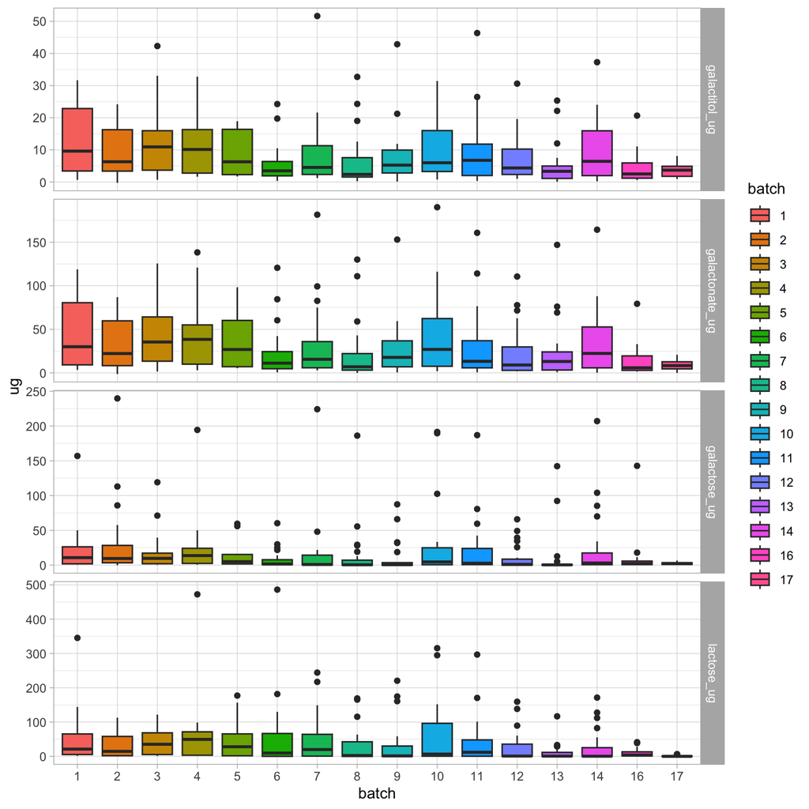

```r
boxplot_after_urine_normalization
```

```r
samples = data_normalized %>%
  filter(!is.na(screen_group)) %>%
  filter(!grepl("_AH", Name)) %>%
  mutate(
    timepoint = factor(
      case_when(
        grepl("_BL", Name) ~ "Baseline",
        grepl("_0-3", Name) ~ "0-3h",
        grepl("_3-6", Name) ~ "3-6h"),
      levels = c("Baseline", "0-3h", "3-6h")
    ),
    screen_group = factor(
      case_when(
        screen_group == 1 ~ "Control",
        screen_group == 2 ~ "LM-A",
        screen_group == 3 ~ "LM-S"
      ),
      levels = c("Control", "LM-A", "LM-S")
    ),
    treatment = factor(
      case_when(
        treatment == "Treatment A" ~ "Lactose",
        treatment == "Treatment B" ~ "Glucose"
      ),
      levels = c("Lactose", "Glucose")
    )
  )
```

## Exploratory data analysis

Now that we have quantified and normalized the data, let’s explore it to see if there are any clear patterns or sources of variation that need to be accounted for.

### PCA

Below is a PCA of the urine-normalized data. From these plots, we can get the following conclusions:

- There do not seem to be any strong batch effects, since samples do not cluster by batch.
- Time points account for most of the variability in the data.
- Baseline samples are more similar to samples treated with glucose at any time point.
- Samples treated with lactose at 0-3 hours (p1) and 3-6 hours (p2) separate by a participant being lactase deficient or not.

```r
# Group and correct compounds of interest
vars = c("galactose_ug", "lactose_ug", "galactitol_ug", "galactonate_ug")

# PCA
pca_df = samples %>%
    select(Name, all_of(vars)) %>%
    # unite("id", study_id:timepoint, remove = FALSE) %>%
    # select(Name, all_of(vars)) %>%
    tibble::column_to_rownames(var = "Name")

x = prcomp(pca_df, center = TRUE, scale. = TRUE)
plot_df = as.data.frame(x$x)
plot_df$study_id = sapply(rownames(plot_df), function(x) {
  id = strsplit(x, "_")[[1]][1]
  paste0("LB", id)
})
plot_df$timepoint = sapply(rownames(plot_df), function(x) {
  samples %>%
    filter(Name == x) %>%
    pull(timepoint)
})

plot_df$study_group = sapply(rownames(plot_df), function(x) {
  samples %>%
    filter(Name == x) %>%
    pull(screen_group)
})

plot_df$batch = sapply(rownames(plot_df), function(x) {
  samples %>%
    filter(Name == x) %>%
    pull(batch)
})

plot_df$intervention = sapply(rownames(plot_df), function(x) {
  samples %>%
    filter(Name == x) %>%
    pull(treatment)
})

plot_df$genotype = sapply(rownames(plot_df), function(x) {
  mapping %>%
    filter(Name == x) %>%
    pull(gen_test_rs4988235)
})

plot_df$study_group = factor(plot_df$study_group)
plot_df$batch = factor(plot_df$batch)
plot_df$intervention = factor(plot_df$intervention)
plot_df$timepoint = factor(plot_df$timepoint, levels = c("Baseline", "0-3h", "3-6h"))
plot_df$genotype = factor(plot_df$genotype, levels = c("TT", "CT", "CC"))

p1 = ggplot(plot_df, aes(x = PC1, y = PC2, color = study_group)) +
    geom_point() +
    theme_light()
# ggsave(file.path(output_dir, "analysis_pca_color_study_group.pdf"), p1)
p2 = ggplot(plot_df, aes(x = PC1, y = PC2, color = batch)) +
    geom_point() +
    theme_light()
# ggsave(file.path(output_dir, "analysis_pca_color_batch.pdf"), p2)
p3 = ggplot(plot_df, aes(x = PC1, y = PC2, color = study_group)) +
    geom_point() +
    facet_grid(intervention ~ timepoint) +
    guides(
      color = guide_legend(title = "Screen group")
    ) +
    scale_color_manual(
      values = c(
        "Control" = "#619CFF",
        "LM-A" = "#00BA38",
        "LM-S" = "#F8766D"
      )
    ) +
    theme_light()

p4 = ggplot(plot_df %>% filter(!is.na(genotype)), aes(x = PC1, y = PC2, color = genotype)) +
    geom_point() +
    facet_grid(intervention ~ timepoint) +
    guides(
      color = guide_legend(title = "Genotype")
    ) +
    scale_color_manual(
      values = c(
        "TT" = "#619CFF",
        "CT" = "#00BA38",
        "CC" = "#F8766D"
      )
    ) +
    theme_light()
# ggsave(file.path(output_dir, "analysis_pca_color_intervention.pdf"), p3)
```

#### PCA colored by batch

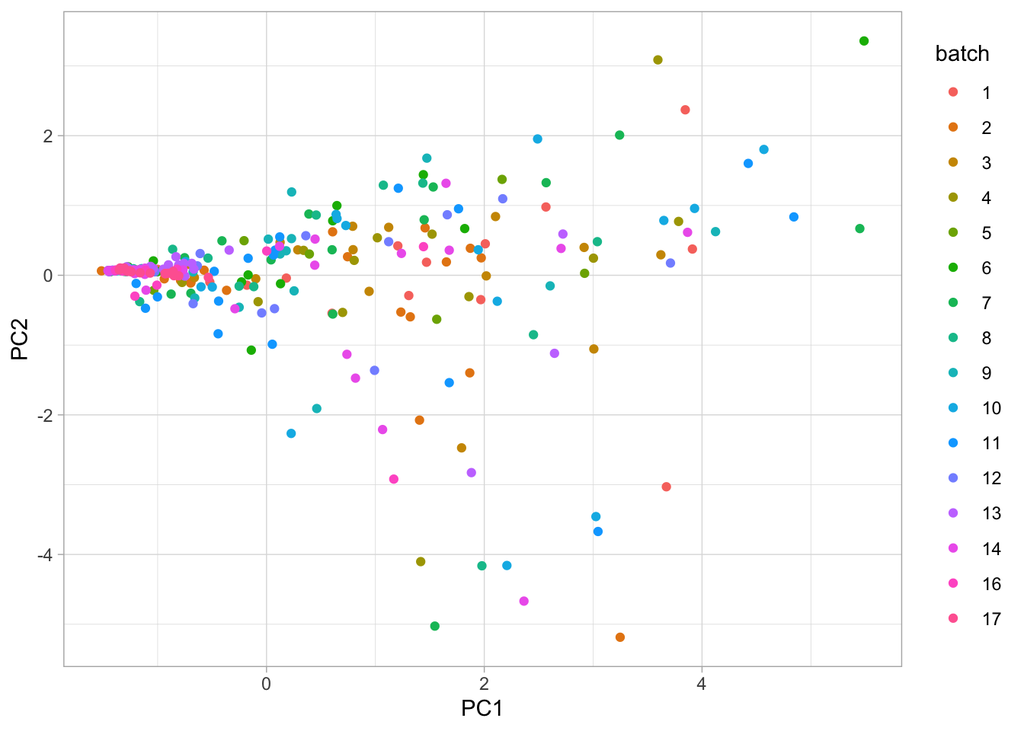

```r
ggsave(file.path(eda_plots_dir, "PCA_by_batch.pdf"), p2)
p2
```

#### PCA colored by screen group, faceted by time point and treatment

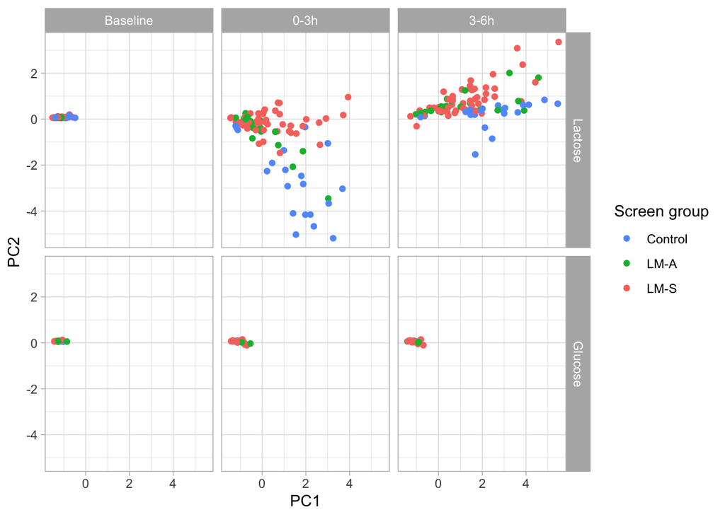

```r
ggsave(file.path(eda_plots_dir, "PCA_by_screen_group_and_time.pdf"), p3)
p3
```

#### PCA colored by genotype, faceted by time point and treatment

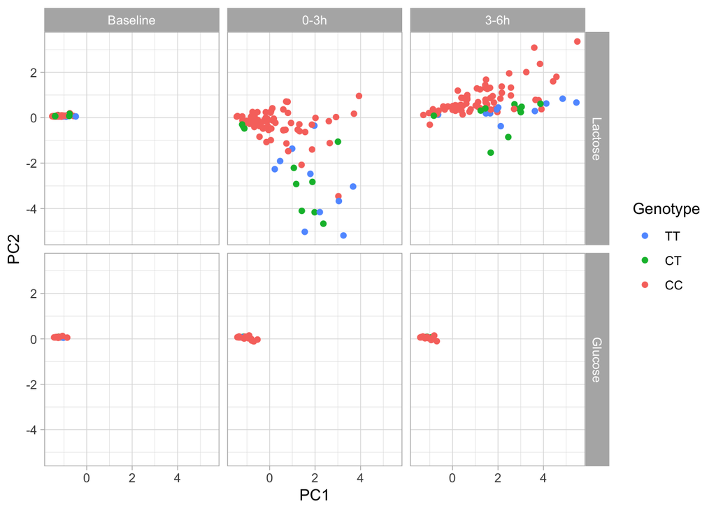

```r
ggsave(file.path(eda_plots_dir, "PCA_by_genotype_and_time.pdf"), p4)
p4
```

### Sample-sample correlation heatmap

Just as a different visualization, we will plot a heatmap with all sample-sample pairwise correlations.

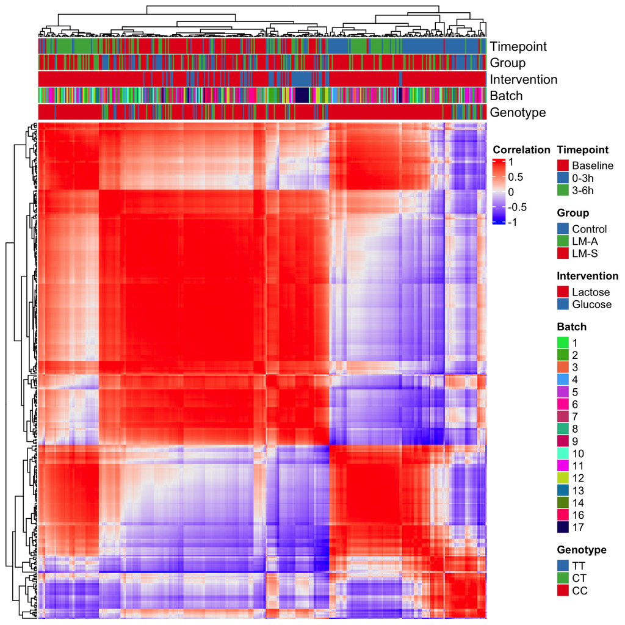

```r
# Sample-sample correlation
heatmaps_df = pca_df
    # filter(!rownames(pca_df) %in% outliers)
cor_mat = cor(t(heatmaps_df))

annots_groups = sapply(rownames(cor_mat), function(x) {
  samples %>%
    filter(Name == x) %>%
    pull(screen_group)
    # unique(samples$screen_group[samples$study_id == id])
})
annots_times = sapply(rownames(cor_mat), function(x) {
    samples %>%
      filter(Name == x) %>%
      pull(timepoint)
})
annots_intervention = sapply(rownames(cor_mat), function(x) {
    # id = strsplit(x, "_")[[1]][1]
    # unique(samples$treatment[samples$study_id == id])
  samples %>%
    filter(Name == x) %>%
    pull(treatment)
})
annots_batch = sapply(rownames(cor_mat), function(x) {
    # id = strsplit(x, "_")[[1]][1]
    # unique(samples$batch[samples$study_id == id])
  samples %>%
    filter(Name == x) %>%
    pull(batch)
})

annots_genotype = sapply(rownames(cor_mat), function(x) {
  mapping %>%
    filter(Name == x) %>%
    pull(gen_test_rs4988235)
})


ha = HeatmapAnnotation(
    Timepoint = as.factor(annots_times),
    Group = as.factor(annots_groups),
    Intervention = as.factor(annots_intervention),
    Batch = as.factor(annots_batch),
    Genotype = as.factor(annots_genotype),
    col = list(
        Timepoint = c(
            "Baseline" = "#E41A1CFF",
            "0-3h" = "#377EB8FF",
            "3-6h" = "#4DAF4AFF"
        ),
        Group = c(
            "Control" = "#377EB8FF",
            "LM-A" = "#4DAF4AFF",
            "LM-S" = "#E41A1CFF"
        ),
        Intervention = c(
            "Lactose" = "#E41A1CFF",
            "Glucose" = "#377EB8FF"
        ),
        Genotype = c(
          "TT" = "#377EB8FF",
          "CT" = "#4DAF4AFF",
          "CC" = "#E41A1CFF"
        )
    )
)

h = Heatmap(
    cor_mat,
    top_annotation = ha,
    show_column_names = FALSE,
    show_row_names = FALSE,
    heatmap_legend_param = list(title = "Correlation")
)

draw(h)
```

```r
# pdf(file.path(output_dir, "correlation_heatmap.pdf"))
# draw(h)
# dev.off()
```

We can see that samples separate very well by timepoint. In addition, we do not see samples clustering by batch (which is good), and groups 2 and 3 tend to be more correlated in the postprandrial timepoints. Finally, treatment B samples in the postprandrial timepoints also group together.

### Boxplots

```r
# Pivot compounds to rows
samples_cr = samples %>%
  select(study_id, screen_group, sex, timepoint, treatment, all_of(vars)) %>%
  pivot_longer(cols = all_of(vars), names_to = "compound", values_to = "value")

write.table(
  samples_cr,
  file.path(raw_results_dir, "samples_cr.tsv"),
  sep = "\t",
  col.names = TRUE,
  row.names = FALSE,
  quote = FALSE
)
```

#### Average dynamics

```r
# Plot avg per group
average_dynamics = samples_cr %>%
  mutate(screen_group = factor(screen_group)) %>%
  group_by(compound, screen_group, treatment, timepoint) %>%
  summarise(avg = mean(value), n = n(), std_err = sd(value) / n()) %>%
  ggplot(aes(x = timepoint, y = avg, color = screen_group, linetype = treatment, group = interaction(screen_group, treatment))) +
    geom_line() +
    geom_point() +
    geom_ribbon(aes(ymin = avg - std_err, ymax = avg + std_err, fill = screen_group, color = NULL), alpha = 0.4) +
    ggtitle("Average metabolite amount per group and treatment") +
    xlab("Time point") +
    ylab("Average amount") +
    facet_grid(compound ~ ., scales = "free_y") +
    guides(
      color = guide_legend(title = "Screen group"),
      linetype = guide_legend(title = "Treatment")
    ) +
    scale_color_manual(
      values = c(
        "Control" = "#619CFF",
        "LM-A" = "#00BA38",
        "LM-S" = "#F8766D"
      )
    ) +
  scale_fill_manual(
    values = c(
      "Control" = "#619CFF",
      "LM-A" = "#00BA38",
      "LM-S" = "#F8766D"
    )
  ) +
    theme_light()

ggsave(file.path(eda_plots_dir, "average_dynamics.pdf"), average_dynamics)
```

#### Timewise comparison by treatment

##### By screen group

The plot below shows the distribution of metabolite values for each group across all time points, separated by treatment. All metabolites seem to show the expected trends in participants that were given lactose.

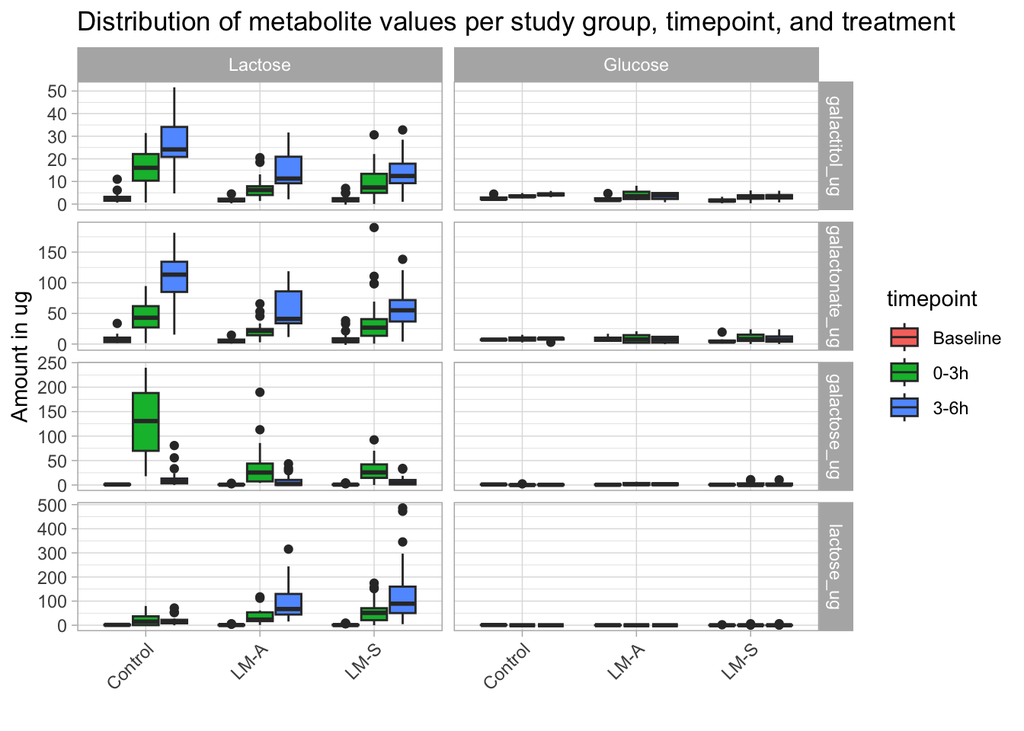

```r
# Plot boxplots
within_group_timewise_plot = samples_cr %>%
  filter(!is.na(treatment)) %>%
  mutate(screen_group = factor(screen_group)) %>%
  ggplot(aes(x = screen_group, y = value, fill = timepoint, group = interaction(timepoint, screen_group))) +
    geom_boxplot() +
    ggtitle("Distribution of metabolite values per study group, timepoint, and treatment") +
    facet_grid(compound ~ treatment, scales = "free_y") +
    xlab("") +
    ylab("Amount in ug") +
    theme_light() +
    theme(axis.text.x = element_text(angle = 45, hjust = 1))

ggsave(file.path(eda_plots_dir, "within_group_timewise_plot.pdf"), within_group_timewise_plot)
within_group_timewise_plot
```

##### By genotype

The plot below shows the distribution of metabolite values for each genotype across all time points, separated by treatment. All metabolites seem to show the expected trends in participants that were given lactose.

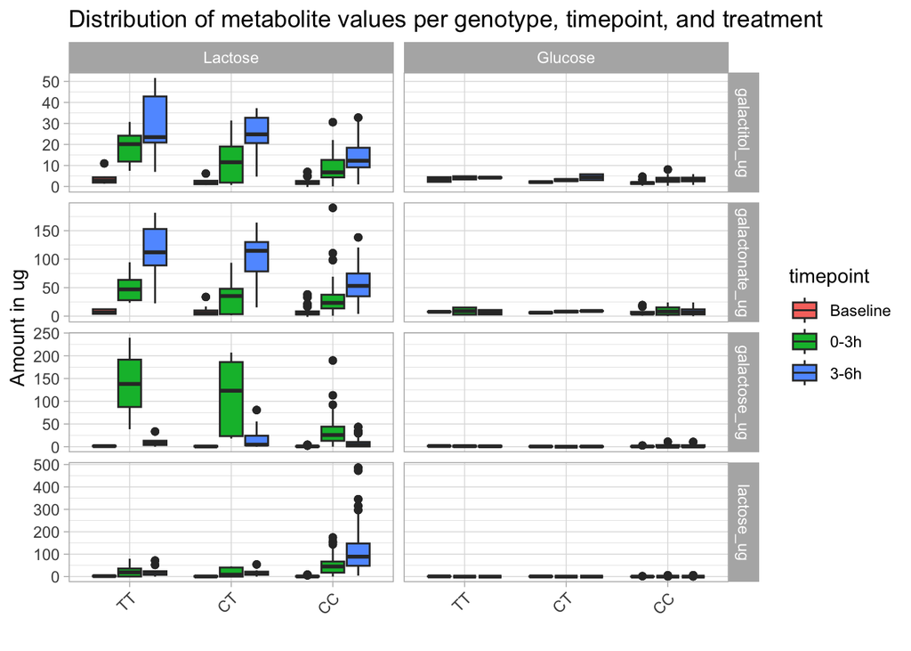

```r
# Plot boxplots
within_genotype_timewise_plot = samples_cr %>%
  inner_join(mapping %>% select(study_id_lb, gen_test_rs4988235), by = join_by("study_id" == "study_id_lb")) %>%
  filter(!is.na(treatment)) %>%
  filter(!is.na(gen_test_rs4988235)) %>%
  mutate(gen_test_rs4988235 = factor(gen_test_rs4988235)) %>%
  ggplot(aes(
    x = gen_test_rs4988235,
    y = value,
    fill = timepoint,
    # group = interaction(timepoint, gen_test_rs4988235))
  )) +
    geom_boxplot() +
    ggtitle("Distribution of metabolite values per genotype, timepoint, and treatment") +
    facet_grid(compound ~ treatment, scales = "free_y") +
    xlab("") +
    ylab("Amount in ug") +
    theme_light() +
    theme(axis.text.x = element_text(angle = 45, hjust = 1))

ggsave(file.path(eda_plots_dir, "within_genotype_timewise_plot.pdf"), within_genotype_timewise_plot)
within_genotype_timewise_plot
```